# Notebook

## Data Scientists Guide to Clustering: Customer Insights with K-Means and Hierarchical Clustering.

Clustering is a fundamental technique in unsupervised machine learning that involves grouping data points into clusters based on their similarities. In this blog, we will delve into the concepts of K-Means and Hierarchical Clustering, explore their applications using a practical dataset, and understand various metrics to evaluate their performance. By the end, you'll have a solid grasp of how to implement and interpret these clustering techniques.

### Introduction to Clustering

Clustering helps in identifying patterns and structures within data without any prior labels. It is widely used in `customer segmentation`, `image segmentation`, `anomaly detection`, and more. We will focus on two popular clustering methods: `K-Means` and `Hierarchical Clustering`.

### The Dataset

We will use a `dataset` containing information about `mall customers`, including their `gender`, `age`, `annual income`, and `spending score`. This data is ideal for demonstrating clustering techniques aimed at segmenting customers based on their annual income and spending scores.

### Their Importance & How to Import the Necessary 🐍Python Libraries Required for Clustering.

To perform clustering and analyze our data effectively, we need several libraries that provide essential functionalities:

```
import pandas as pd
import matplotlib.pyplot as plt
import seaborn as sns
from sklearn.preprocessing import MinMaxScaler
from sklearn.cluster import KMeans, AgglomerativeClustering
from sklearn.metrics import silhouette_score, davies_bouldin_score
import scipy.cluster.hierarchy as sch
```

#### Explanation of Imports:

1. **pandas (`pd`)**:
   - **Purpose**: To handle and manipulate data efficiently.
   - **Usage**: We use pandas to load our dataset, perform data cleaning, and prepare data for clustering. It provides data structures like DataFrames, which are essential for managing structured data.
2. **matplotlib.pyplot (`plt`)**:
   - **Purpose**: To create static, animated, and interactive visualizations.
   - **Usage**: We use matplotlib to plot graphs and charts, such as scatter plots and the Elbow Method plot, to visualize data distributions and clustering results.
3. **seaborn (`sns`)**:
   - **Purpose**: To make statistical data visualization easy and attractive.
   - **Usage**: Seaborn works well with pandas DataFrames and is used for creating more complex visualizations, like pair plots and count plots, to analyze data distributions and cluster counts.
4. **sklearn.preprocessing.MinMaxScaler**:
   - **Purpose**: To scale features to a specific range, usually [0, 1].
   - **Usage**: Scaling ensures that all features contribute equally to the distance calculations in clustering algorithms, preventing features with larger magnitudes from dominating the clustering process.
5. **sklearn.cluster.KMeans, AgglomerativeClustering**:
   - **Purpose**: To implement clustering algorithms.
   - **Usage**: `KMeans` and `AgglomerativeClustering` are used to create clusters based on the data. K-Means partitions data into K clusters, while Agglomerative Clustering builds a hierarchy of clusters.
6. **sklearn.metrics.silhouette_score, davies_bouldin_score**:
   - **Purpose**: To evaluate the quality of clustering.
   - **Usage**: `silhouette_score` measures how similar an object is to its own cluster compared to other clusters. `davies_bouldin_score` evaluates the average similarity ratio of each cluster with its most similar cluster, where a lower score indicates better clustering.
7. **scipy.cluster.hierarchy (`sch`)**:
   - **Purpose**: To perform hierarchical clustering and create dendrograms.
   - **Usage**: We use `sch` to generate dendrograms, which help visualize the hierarchical structure of clusters and determine the optimal number of clusters.

These libraries provide the necessary tools to load, preprocess, visualize, and cluster the data, as well as evaluate the clustering results effectively.

```python
# Importing the necessary libraries
import pandas as pd
import matplotlib.pyplot as plt
import seaborn as sns
from sklearn.preprocessing import MinMaxScaler
from sklearn.cluster import KMeans, AgglomerativeClustering
from sklearn.metrics import silhouette_score, davies_bouldin_score
import scipy.cluster.hierarchy as sch
%matplotlib inline
```

```python
# Load the dataset
data = pd.read_csv('https://raw.githubusercontent.com/Explore-AI/Public-Data/master/Data/unsupervised_sprint/mall_customers.csv', index_col=0)
data.head()
```

| CustomerID | Genre | Age | Annual_Income_(k$) | Spending_Score |
| --- | --- | --- | --- | --- |
| 1 | Male | 19 | 15 | 39 |
| 2 | Male | 21 | 15 | 81 |
| 3 | Female | 20 | 16 | 6 |
| 4 | Female | 23 | 16 | 77 |
| 5 | Female | 31 | 17 | 40 |

`Notes: The Gender column is misspelt. For futher manipulations we could cache the Data from Github or use Pandas`

The head of our data shows demographic and spending information for mall customers, including `Genre`, `Age`, `Annual_Income_(k$)`, and `Spending_Score`. We observe diverse age groups, income levels, and spending behaviors, with both genders represented. This variety supports robust clustering analysis.

### Descriptive Statistics

Before diving into clustering, it's essential to understand the dataset's characteristics. Descriptive statistics provide a summary of the central tendency, dispersion, and shape of the dataset’s distribution. This helps us identify any anomalies or patterns in the data, ensuring that the data is suitable for clustering. By examining metrics such as the mean, median, standard deviation, minimum, and maximum values, we can better understand the distribution of variables like `Age`, `Annual_Income_(k$)`, and `Spending_Score`. This preliminary analysis is crucial for making informed decisions during the preprocessing and clustering stages. Let's print the descriptive statistics.

```
print(data.describe())
```

**Insight**: The descriptive statistics will help us understand the range and distribution of the spending behaviors and incomes, identify any outliers, and ensure that our data is ready for the clustering process.

```python
print(data.describe())
```

```
              Age  Annual_Income_(k$)  Spending_Score
count  200.000000          200.000000      200.000000
mean    38.850000           60.560000       50.200000
std     13.969007           26.264721       25.823522
min     18.000000           15.000000        1.000000
25%     28.750000           41.500000       34.750000
50%     36.000000           61.500000       50.000000
75%     49.000000           78.000000       73.000000
max     70.000000          137.000000       99.000000
```

The descriptive statistics table provides a summary of the central tendency, dispersion, and range of the dataset’s features: `Age`, `Annual_Income_(k$)`, and `Spending_Score`.

### Insights from Descriptive Statistics

**Age**:

- **Count**: 200 observations.
- **Mean**: The average age of customers is approximately 38.85 years.
- **Standard Deviation (std)**: There is a variability of about 13.97 years around the mean age.
- **Minimum (min)**: The youngest customer is 18 years old.
- **25th Percentile (25%)**: 25% of the customers are 28.75 years or younger.
- **Median (50%)**: The median age is 36 years, indicating that half of the customers are below this age and half are above.
- **75th Percentile (75%)**: 25% of the customers are 49 years or older.
- **Maximum (max)**: The oldest customer is 70 years old.

**Annual Income (k$)**:

- **Count**: 200 observations.
- **Mean**: The average annual income is $60.56k.
- **Standard Deviation (std)**: The annual income varies by about $26.26k.
- **Minimum (min)**: The lowest annual income is $15k.
- **25th Percentile (25%)**: 25% of the customers earn $41.5k or less annually.
- **Median (50%)**: The median annual income is $61.5k, meaning half of the customers earn less than this amount and half earn more.
- **75th Percentile (75%)**: 25% of the customers earn $78k or more annually.
- **Maximum (max)**: The highest annual income is $137k.

**Spending Score**:

- **Count**: 200 observations.
- **Mean**: The average spending score is 50.2.
- **Standard Deviation (std)**: The spending score varies by about 25.82.
- **Minimum (min)**: The lowest spending score is 1.
- **25th Percentile (25%)**: 25% of the customers have a spending score of 34.75 or lower.
- **Median (50%)**: The median spending score is 50, indicating that half of the customers have a score below this value and half above.
- **75th Percentile (75%)**: 25% of the customers have a spending score of 73 or higher.
- **Maximum (max)**: The highest spending score is 99.

### Key Takeaways

- **Age Distribution**: The age of customers ranges from 18 to 70 years, with an average around 38.85 years. The age distribution shows a reasonable spread with no extreme outliers.
- **Income Distribution**: Annual incomes range from $15k to $137k, with an average income of $60.56k. The data includes a broad spectrum of income levels, which will be useful for clustering customers based on their spending capacity.
- **Spending Score Distribution**: The spending scores range from 1 to 99, with an average score of 50.2. This wide range indicates diverse spending behaviors among the customers, which is crucial for identifying different customer segments.

These insights provide a solid foundation for understanding the dataset's structure and are essential for the subsequent clustering analysis. Next, we'll visualize these statistics to further explore the data distribution and identify any potential patterns or anomalies.

### Visualization of Feature Distributions and Interpreting Descriptive Statistics

The histograms and box plots below provide a visual summary of the distributions of the key features in our dataset: `Age`, `Annual_Income_(k$)`, and `Spending_Score`. These visualizations help us to understand the data better by highlighting patterns, skewness, and potential outliers.

Here is the code to generate the histograms and box plots:

```
import matplotlib.pyplot as plt
import seaborn as sns

# Set the style
sns.set(style="whitegrid")

# Create a figure with subplots
fig, axes = plt.subplots(3, 2, figsize=(18, 18))

# Histogram for Age
sns.histplot(data['Age'], bins=15, kde=True, ax=axes[0, 0], color='teal', legend=True)
axes[0, 0].set_title('Age Distribution', fontsize=16)
axes[0, 0].set_xlabel('Age', fontsize=14)
axes[0, 0].set_ylabel('Frequency', fontsize=14)

# Box plot for Age
sns.boxplot(y=data['Age'], ax=axes[0, 1], color='teal')
axes[0, 1].set_title('Age Box Plot', fontsize=16)
axes[0, 1].set_xlabel('Age', fontsize=14)

# Histogram for Annual Income
sns.histplot(data['Annual_Income_(k$)'], bins=15, kde=True, ax=axes[1, 0], color='coral', legend=True)
axes[1, 0].set_title('Annual Income Distribution', fontsize=16)
axes[1, 0].set_xlabel('Annual Income (k$)', fontsize=14)
axes[1, 0].set_ylabel('Frequency', fontsize=14)

# Box plot for Annual Income
sns.boxplot(y=data['Annual_Income_(k$)'], ax=axes[1, 1], color='coral')
axes[1, 1].set_title('Annual Income Box Plot', fontsize=16)
axes[1, 1].set_xlabel('Annual Income (k$)', fontsize=14)

# Histogram for Spending Score
sns.histplot(data['Spending_Score'], bins=15, kde=True, ax=axes[2, 0], color='purple', legend=True)
axes[2, 0].set_title('Spending Score Distribution', fontsize=16)
axes[2, 0].set_xlabel('Spending Score', fontsize=14)
axes[2, 0].set_ylabel('Frequency', fontsize=14)

# Box plot for Spending Score
sns.boxplot(y=data['Spending_Score'], ax=axes[2, 1], color='purple')
axes[2, 1].set_title('Spending Score Box Plot', fontsize=16)
axes[2, 1].set_xlabel('Spending Score', fontsize=14)

# Adjust layout
plt.tight_layout()
plt.show()
```

### Code Explanation

1. **Import Libraries**:

   ```
   import matplotlib.pyplot as plt
   import seaborn as sns
   ```

   We use `matplotlib` for plotting and `seaborn` for creating attractive and informative statistical graphics.
2. **Set the Style**:

   ```
   sns.set(style="whitegrid")
   ```

   This sets the aesthetic style of the plots to a clean white grid.
3. **Create a Figure with Subplots**:

   ```
   fig, axes = plt.subplots(3, 2, figsize=(18, 18))
   ```

   This line creates a figure with six subplots arranged in a 3x2 grid. Each subplot will hold one histogram or box plot.
4. **Histogram for Age**:

   ```
   sns.histplot(data['Age'], bins=15, kde=True, ax=axes[0, 0], color='teal', legend=True)
   axes[0, 0].set_title('Age Distribution', fontsize=16)
   axes[0, 0].set_xlabel('Age', fontsize=14)
   axes[0, 0].set_ylabel('Frequency', fontsize=14)
   ```

   We create a histogram for the `Age` feature with 15 bins and a KDE (Kernel Density Estimate) line for smooth distribution visualization.
5. **Box Plot for Age**:

   ```
   sns.boxplot(y=data['Age'], ax=axes[0, 1], color='teal')
   axes[0, 1].set_title('Age Box Plot', fontsize=16)
   axes[0, 1].set_xlabel('Age', fontsize=14)
   ```

   We create a box plot for the `Age` feature to show the distribution, central value, and outliers.
6. **Histogram for Annual Income**:

   ```
   sns.histplot(data['Annual_Income_(k$)'], bins=15, kde=True, ax=axes[1, 0], color='coral', legend=True)
   axes[1, 0].set_title('Annual Income Distribution', fontsize=16)
   axes[1, 0].set_xlabel('Annual Income (k$)', fontsize=14)
   axes[1, 0].set_ylabel('Frequency', fontsize=14)
   ```

   Similarly, we create a histogram for the `Annual_Income_(k$)` feature.
7. **Box Plot for Annual Income**:

   ```
   sns.boxplot(y=data['Annual_Income_(k$)'], ax=axes[1, 1], color='coral')
   axes[1, 1].set_title('Annual Income Box Plot', fontsize=16)
   axes[1, 1].set_xlabel('Annual Income (k$)', fontsize=14)
   ```

   We create a box plot for the `Annual_Income_(k$)` feature.
8. **Histogram for Spending Score**:

   ```
   sns.histplot(data['Spending_Score'], bins=15, kde=True, ax=axes[2, 0], color='purple', legend=True)
   axes[2, 0].set_title('Spending Score Distribution', fontsize=16)
   axes[2, 0].set_xlabel('Spending Score', fontsize=14)
   axes[2, 0].set_ylabel('Frequency', fontsize=14)
   ```

   We create a histogram for the `Spending_Score` feature.
9. **Box Plot for Spending Score**:

   ```
   sns.boxplot(y=data['Spending_Score'], ax=axes[2, 1], color='purple')
   axes[2, 1].set_title('Spending Score Box Plot', fontsize=16)
   axes[2, 1].set_xlabel('Spending Score', fontsize=14)
   ```

   We create a box plot for the `Spending_Score` feature.
10. **Adjust Layout and Show Plot**:

    ```
    plt.tight_layout()
    plt.show()
    ```

    The `tight_layout()` function adjusts the subplot parameters to give some padding and prevent overlapping, and `show()` displays the plots.

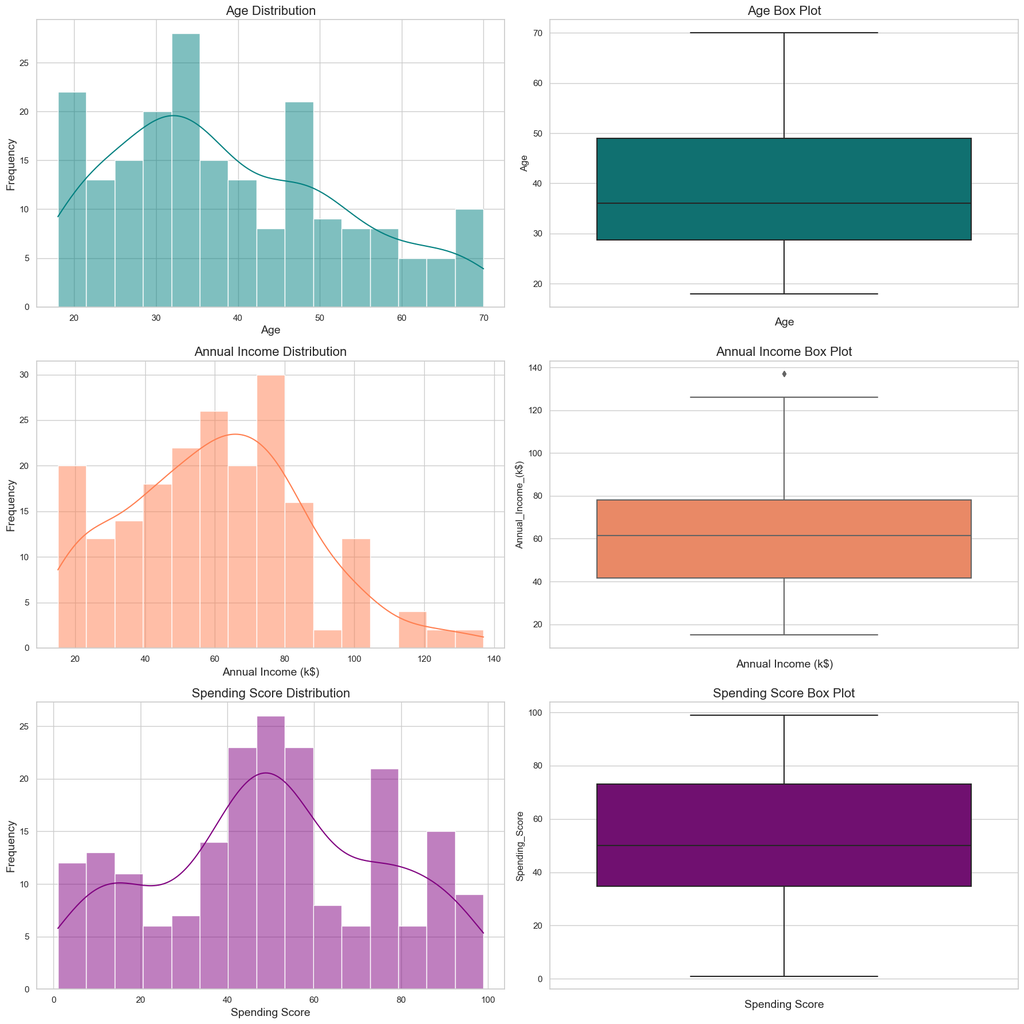

```python
import matplotlib.pyplot as plt
import seaborn as sns

# Set the style
sns.set(style="whitegrid")

# Create a figure with subplots
fig, axes = plt.subplots(3, 2, figsize=(18, 18))

# Histogram for Age
sns.histplot(data['Age'], bins=15, kde=True, ax=axes[0, 0], color='teal', legend=True)
axes[0, 0].set_title('Age Distribution', fontsize=16)
axes[0, 0].set_xlabel('Age', fontsize=14)
axes[0, 0].set_ylabel('Frequency', fontsize=14)

# Box plot for Age
sns.boxplot(y=data['Age'], ax=axes[0, 1], color='teal')
axes[0, 1].set_title('Age Box Plot', fontsize=16)
axes[0, 1].set_xlabel('Age', fontsize=14)

# Histogram for Annual Income
sns.histplot(data['Annual_Income_(k$)'], bins=15, kde=True, ax=axes[1, 0], color='coral', legend=True)
axes[1, 0].set_title('Annual Income Distribution', fontsize=16)
axes[1, 0].set_xlabel('Annual Income (k$)', fontsize=14)
axes[1, 0].set_ylabel('Frequency', fontsize=14)

# Box plot for Annual Income
sns.boxplot(y=data['Annual_Income_(k$)'], ax=axes[1, 1], color='coral')
axes[1, 1].set_title('Annual Income Box Plot', fontsize=16)
axes[1, 1].set_xlabel('Annual Income (k$)', fontsize=14)

# Histogram for Spending Score
sns.histplot(data['Spending_Score'], bins=15, kde=True, ax=axes[2, 0], color='purple', legend=True)
axes[2, 0].set_title('Spending Score Distribution', fontsize=16)
axes[2, 0].set_xlabel('Spending Score', fontsize=14)
axes[2, 0].set_ylabel('Frequency', fontsize=14)

# Box plot for Spending Score
sns.boxplot(y=data['Spending_Score'], ax=axes[2, 1], color='purple')
axes[2, 1].set_title('Spending Score Box Plot', fontsize=16)
axes[2, 1].set_xlabel('Spending Score', fontsize=14)

# Adjust layout
plt.tight_layout()
plt.show()
```

[figure not shown]

### Explanation and Insights from our Plots.

- **Histograms**: Show the frequency distribution of each feature.
- **Box Plots**: Highlight the median, quartiles, and outliers.

#### Age Distribution

- **Histogram**: The age distribution shows a varied range of customers, with most ages distributed between 20 and 60 years. There is a noticeable peak around the mid-30s.
- **Box Plot**: The box plot confirms that the ages are spread out, with a median around 36 years. There are no significant outliers, indicating a fairly uniform distribution.

#### Annual Income Distribution

- **Histogram**: Annual incomes show a relatively normal distribution with a peak around $60k. There are some higher incomes, but they taper off significantly after $100k.
- **Box Plot**: The box plot indicates a median annual income of about $61.5k, with one noticeable outlier above $120k. This suggests that while most customers have moderate incomes, there are a few with significantly higher earnings.

These histograms and box plots provide a comprehensive overview of the dataset, helping us identify patterns, skewness, and potential outliers. This understanding is crucial before applying clustering algorithms to ensure accurate and meaningful insights.

### Importance of Interpreting Observations in Our Dataset

Understanding the scale and characteristics of our dataset through descriptive statistics and visualizations is crucial for several reasons:

1. **Data Quality**: Identifying and handling outliers, missing values, and inconsistencies ensures that our dataset is clean and reliable.
2. **Feature Distribution**: Knowing how our features are distributed helps in selecting appropriate preprocessing steps, such as scaling, which is vital for clustering algorithms to perform correctly.
3. **Cluster Analysis**: Insights into the data distributions allow us to make informed decisions when choosing clustering methods and parameters, leading to more meaningful and actionable clusters.
4. **Anomaly Detection**: Recognizing patterns and anomalies within our data can help us identify and address unusual behaviors or errors early in the analysis process.

### Number of Observations

To understand the scale of our data, let's find the total number of observations.

```
print("To understand the scale of our data, let's find the total number of observations.")


print(f'Total number is {data.shape[0]} observations in the dataset.')
```

**Answer**: To understand the scale of our data, let's find the total number of observations.

**Answer**: There are `200 observations` in the `dataset`.

**Explanation**: Knowing the total number of observations is crucial as it influences our choice of `clustering algorithms` and their `parameters`. With `200 observations`, we can use algorithms like `K-Means` and `Hierarchical Clustering` effectively without significant `computational constraints`. It also helps us gauge the representativeness of our `sample size` and ensures that our `clusters` are formed based on `sufficient data points`.

Understanding the number of observations in our dataset influences our subsequent clustering efforts. It helps in:

- **Resource Allocation**: Knowing the dataset size allows for proper resource allocation, especially when dealing with large datasets that may require more computational power.
- **Cluster Size**: It helps in determining an appropriate number of clusters. For a smaller dataset, fewer clusters might be more appropriate, whereas a larger dataset might benefit from more clusters to capture the nuances in the data.
- **Model Complexity**: The number of observations can guide the complexity of the model we choose. Larger datasets might support more complex models without overfitting, while simpler models might be more appropriate for smaller datasets.

By thoroughly examining our dataset's descriptive statistics and visualizations, we lay a strong foundation for effective clustering and subsequent analysis. This process ensures that the insights we derive are accurate and meaningful.

```python
#Number of Observations

print("To understand the scale of our data, let's find the total number of observations.")


print(f'Total number is {data.shape[0]} observations in the dataset.')

print(data.isnull().sum())
```

```
To understand the scale of our data, let's find the total number of observations.
Total number is 200 observations in the dataset.
Genre                 0
Age                   0
Annual_Income_(k$)    0
Spending_Score        0
dtype: int64
```

### Handling Null Values

Missing values can disrupt the clustering process. Let's check for null values and handle them if necessary.

```
print(data.isnull().sum())
```

**Insight**: The dataset contains no null values, so we can proceed without any imputation.

### Why We Need to Handle Null Values

Handling null values is crucial because:

1. **Algorithm Compatibility**: Most machine learning algorithms, including clustering algorithms, do not handle null values well. They require complete datasets to perform calculations.
2. **Data Integrity**: Null values can lead to biased results, as they may represent missing information that could skew the analysis if not handled properly.
3. **Accuracy**: Filling in or removing null values ensures that the model is trained on accurate and complete data, which improves the model’s predictive accuracy and reliability.
4. **Consistency**: Handling null values maintains the consistency and integrity of the dataset, ensuring that all data points are valid and comparable.

By thoroughly `examining` our dataset's descriptive statistics and visualizations, and ensuring there are `no null` values, we lay a `strong foundation` for `effective clustering` and `subsequent analysis`. This process ensures that the `insights` we derive are `accurate and meaningful`.

```python
#Your code here
# Step 1: Check for null values
null_values = data.isnull().sum()
print("Null values before filling:")
print(null_values)

# Step 2: Fill null values with zeros
data_filled = data.fillna(0)

# Step 3: Verify no null values remain
null_values_after = data_filled.isnull().sum()
print("Null values after filling:")
print(null_values_after)

# Determine if the dataset initially contained no null values
contains_null_values = null_values.sum() > 0
print(f"Our dataset contains null values: {contains_null_values}")

# Answer
if contains_null_values:
    answer = "False"
else:
    answer = "True"

#print(f"Answer: {answer}")
```

```
Null values before filling:
Genre                 0
Age                   0
Annual_Income_(k$)    0
Spending_Score        0
dtype: int64
Null values after filling:
Genre                 0
Age                   0
Annual_Income_(k$)    0
Spending_Score        0
dtype: int64
Our dataset contains null values: False
```

### Code Explanation

1. **Check for Null Values**:

   ```
   # Step 1: Check for null values
   null_values = data.isnull().sum()
   print("Null values before filling:")
   print(null_values)
   ```

   This step identifies and counts the number of null values in each column of the dataset.
2. **Fill Null Values**:

   ```
   # Step 2: Fill null values with zeros
   data_filled = data.fillna(0)
   ```

   In this step, any null values in the dataset are filled with zeros to ensure the dataset is complete and can be used in clustering algorithms.
3. **Verify No Null Values Remain**:

   ```
   # Step 3: Verify no null values remain
   null_values_after = data_filled.isnull().sum()
   print("Null values after filling:")
   print(null_values_after)
   ```

   This step checks the dataset again to confirm that there are no remaining null values.
4. **Determine if the Dataset Initially Contained Null Values**:

   ```
   # Determine if the dataset initially contained no null values
   contains_null_values = null_values.sum() > 0
   print(f"Our dataset contains null values: {contains_null_values}")

   # Answer
   if contains_null_values:
       answer = "False"
   else:
       answer = "True"
   ```

### Null Values in Our Dataset

Before applying clustering algorithms, it's essential to ensure that our dataset is free from null values, as missing data can disrupt the clustering process. Here's the summary of our null values check:

**Null values before filling:**

```
Genre                 0
Age                   0
Annual_Income_(k$)    0
Spending_Score        0
dtype: int64
```

**Null values after filling:**

```
Genre                 0
Age                   0
Annual_Income_(k$)    0
Spending_Score        0
dtype: int64
```

**Insight**: Our dataset contains no null values, so we can proceed without any imputation.

In summary, confirming that our dataset contains no null values allows us to proceed with clustering confidently, knowing that the data is complete and reliable. This step is crucial for maintaining the quality and accuracy of our clustering analysis.

### Scatter Plot Visualization

To understand the relationship between annual income and spending score, we generate scatter plots using both Matplotlib, Plotly, and Plotnine. This will help us identify any potential clusters in the data.

#### Static Scatter Plot using Matplotlib

```
# Static scatter plot with Matplotlib
plt.figure(figsize=(12, 8))
scatter = plt.scatter(data['Annual_Income_(k$)'], data['Spending_Score'], c=data['Genre'].apply(lambda x: 0 if x == 'Male' else 1), cmap='viridis', edgecolors='b', s=100, alpha=0.7)
plt.title('Relationship between Annual Income and Spending Score', fontsize=16)
plt.xlabel('Annual Income (k$)', fontsize=14)
plt.ylabel('Spending Score', fontsize=14)
plt.grid(True)
# Create a legend
handles, labels = scatter.legend_elements(prop="colors")
legend1 = plt.legend(handles, ['Male', 'Female'], title="Genre", loc="upper right", fontsize=12)
plt.gca().add_artist(legend1)
plt.show()
```

**Insight**: The static scatter plot shows potential clusters forming, particularly in the center of the plot. This initial visualization helps us identify areas where customers with similar spending scores and annual incomes are grouped together.

#### Interactive Scatter Plot using Plotly

To create a more interactive and informative visualization, we use Plotly. This interactive scatter plot allows us to explore the data in greater detail by hovering over data points to see additional information such as age and genre.

```
import plotly.express as px

# Interactive scatter plot with Plotly
fig = px.scatter(data, x='Annual_Income_(k$)', y='Spending_Score', color='Genre',
                 title='Relationship between Annual Income and Spending Score',
                 labels={'Annual_Income_(k$)': 'Annual Income (k$)', 'Spending_Score': 'Spending Score'},
                 template='plotly_dark', size='Age', hover_data=['Age', 'Genre'])
fig.update_layout(title_font_size=20, legend_title_text='Genre', legend_title_font_size=14)
fig.show()
```

**Insight**: The interactive scatter plot provides a dynamic way to explore the relationship between annual income and spending score. By incorporating additional dimensions like age and genre, we can gain deeper insights into the customer segments. The plot reveals distinct clusters, particularly when we consider the genre (male and female) and the age of customers. This visualization makes it easier to identify patterns and potential groupings in the data.

#### Advanced Scatter Plot using Plotnine

Plotnine, which is based on the grammar of graphics, can also be used to create informative and aesthetically pleasing scatter plots similar to those in Tableau or Power BI.

```
from plotnine import ggplot, aes, geom_point, theme_minimal, labs, scale_color_manual

# Generate a scatter plot using plotnine (ggplot2 for Python)
plot = (ggplot(data, aes(x='Annual_Income_(k$)', y='Spending_Score', color='Genre')) +
        geom_point(size=4, alpha=0.7) +
        theme_minimal() +
        labs(title='Relationship between Annual Income and Spending Score',
             x='Annual Income (k$)', y='Spending Score', color='Genre') +
        scale_color_manual(values=['#1f77b4', '#ff7f0e']))
print(plot)
```

**Insight**: This plot provides a clean and professional look, making it easier to identify trends and clusters in the data. The use of different colors for the `Genre` variable enhances the visual appeal and interpretability.

### Importance of Scatter Plot Visualization

- **Identifying Patterns**: Scatter plots are excellent for visualizing the relationship between two variables and identifying potential patterns or clusters.
- **Cluster Detection**: Visualizing the data helps in the preliminary detection of clusters, which can then be confirmed and refined using clustering algorithms.
- **Exploratory Analysis**: Scatter plots are a vital part of exploratory data analysis (EDA), providing a visual way to understand data distributions and relationships.
- **Interactive Insights**: Using interactive tools like Plotly enhances the exploratory process, allowing us to hover over data points and see additional information, making it easier to draw insights from the data.

By using both static and interactive scatter plots, we can gain a comprehensive understanding of the relationships and patterns in our dataset, which is crucial for effective clustering and subsequent analysis.

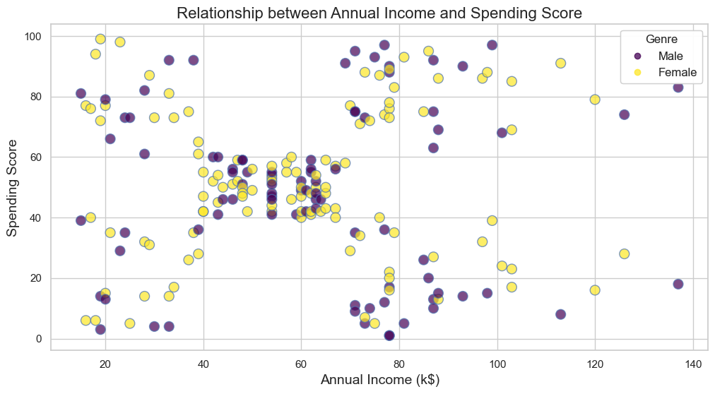

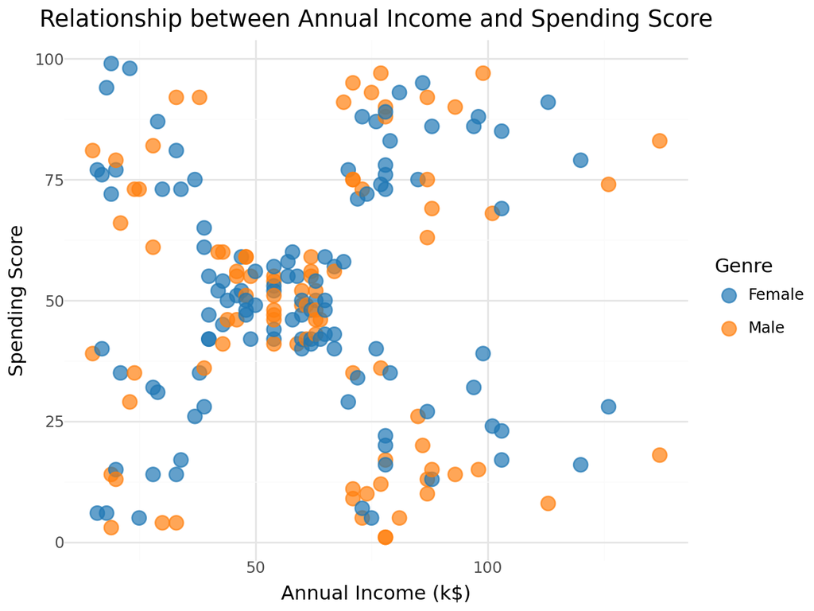

```python
import plotly.express as px
import matplotlib.pyplot as plt

from plotnine import ggplot, aes, geom_point, theme_minimal, labs, scale_color_manual

# Static scatter plot with Matplotlib
plt.figure(figsize=(12, 6))
scatter = plt.scatter(data['Annual_Income_(k$)'], data['Spending_Score'], c=data['Genre'].apply(lambda x: 0 if x == 'Male' else 1), cmap='viridis', edgecolors='b', s=100, alpha=0.7)
plt.title('Relationship between Annual Income and Spending Score', fontsize=16)
plt.xlabel('Annual Income (k$)', fontsize=14)
plt.ylabel('Spending Score', fontsize=14)
plt.grid(True)
# Create a legend
handles, labels = scatter.legend_elements(prop="colors")
legend1 = plt.legend(handles, ['Male', 'Female'], title="Genre", loc="upper right", fontsize=12)
plt.gca().add_artist(legend1)
plt.show()

# Interactive scatter plot with Plotly
fig = px.scatter(data, x='Annual_Income_(k$)', y='Spending_Score', color='Genre',
                 title='Relationship between Annual Income and Spending Score',
                 labels={'Annual_Income_(k$)': 'Annual Income (k$)', 'Spending_Score': 'Spending Score'},
                 template='plotly_dark', size='Age', hover_data=['Age', 'Genre'])
fig.update_layout(title_font_size=20, legend_title_text='Genre', legend_title_font_size=14)
fig.show()

# Generate a scatter plot using plotnine (ggplot2 for Python)
plot = (ggplot(data, aes(x='Annual_Income_(k$)', y='Spending_Score', color='Genre')) +
        geom_point(size=4, alpha=0.7) +
        theme_minimal() +
        labs(title='Relationship between Annual Income and Spending Score',
             x='Annual Income (k$)', y='Spending Score', color='Genre') +
        scale_color_manual(values=['#1f77b4', '#ff7f0e']))
print(plot)
```

### Scatter Plot Visualization

The scatter plots below visualize the relationship between annual income and spending score for the customers in our dataset. These plots are created using different libraries to enhance visual appeal and interactivity.

#### Static Scatter Plot using Matplotlib

The first scatter plot uses Matplotlib, a powerful and flexible Python plotting library, to create a basic static visualization.

**Matplotlib Scatter Plot**:

- **Customization**: The plot now includes a color map (`cmap='viridis'`) and alpha transparency for better visual appeal.
- **Legend**: A custom legend is added to distinguish between 'Male' and 'Female' categories clearly.
- **Grid and Labels**: The grid and labels are styled for better readability.

**Insight**: This scatter plot reveals clusters of data points, particularly in the central region, indicating that customers with certain income levels exhibit similar spending behaviors.

#### Interactive Scatter Plot using Plotly

The second scatter plot is created using Plotly, an interactive plotting library. This plot allows us to hover over data points to see additional information such as age and genre.

**Plotly Interactive Scatter Plot**:

- **Interactivity**: Hovering over data points shows additional information such as age and genre, making the plot interactive and more informative.
- **Template and Style**: The `plotly_dark` template gives the plot a modern look, and the layout adjustments enhance the visual appeal.

**Insight**: The interactive scatter plot enhances the exploration of data relationships by allowing detailed inspection of individual points, showing that male and female customers distribute across different spending scores and income levels.

#### Aesthetic Scatter Plot using ggplot

The third scatter plot employs ggplot, a plotting system for Python based on the grammar of graphics. It provides an elegant and concise way to create aesthetically pleasing plots.

**Plotnine Scatter Plot**:

- **Theme and Colors**: The `theme_minimal()` function provides a clean look, and `scale_color_manual` customizes the colors for better visual distinction between genres.
- **Size and Transparency**: The `size` and `alpha` parameters in `geom_point` enhance readability by adjusting the point size and transparency.

**Insight**: This plot combines aesthetic appeal with clarity, showing potential clusters and highlighting differences in spending behaviors between genders.

### Inference from Scatter Plots

1. **Cluster Identification**: All three plots indicate potential clusters, especially around certain ranges of annual income and spending scores. These clusters suggest that customers can be grouped based on their income and spending patterns.
2. **Gender Differences**: The color-coded points in the Plotly and ggplot visualizations reveal that both male and female customers are distributed across different clusters, with no single gender dominating any particular cluster.
3. **Detailed Insights**: The interactive Plotly plot allows for a more detailed examination of individual data points, providing insights into how age and gender might influence spending behavior.
4. **Visual Appeal**: Using different plotting libraries enhances the visual appeal and readability of the plots, making it easier to communicate insights effectively.
5. **Identifying Patterns**: Scatter plots are excellent for visualizing the relationship between two variables and identifying potential patterns or clusters.
6. **Exploratory Analysis**: Scatter plots are a vital part of exploratory data analysis (EDA), providing a visual way to understand data distributions and relationships.

By using these scatter plots, we can gain a comprehensive understanding of the relationships and patterns in our dataset, which is crucial for effective clustering and subsequent analysis.

### Scaling Data

**Note**: *Not scaling the `Age` column results in better clustering. Initially, this was my experiment to see if scaling `Age` led to better clustering.*

**Finding**: *It did not; the K-means silhouette score drops from `0.56` to `0.402`.*

Scaling is crucial for clustering algorithms to ensure that features contribute equally to the distance calculations. Let's understand why the provided code returns an error and correct it.

```
from sklearn.preprocessing import MinMaxScaler

scaler = MinMaxScaler()
try:
    X_scaled = scaler.fit_transform(data)
except ValueError as e:
    print(e)
```

**Error**: The MinMaxScaler cannot handle non-numeric data, such as the `Gender` column.

**Explanation**: By focusing on `Annual_Income_(k$)` and `Spending_Score`, we avoid the non-numeric `Gender` column and successfully scale the numeric data. This ensures that all features contribute equally to the distance calculations in clustering algorithms.

**Corrected Scaling Process**

```
from sklearn.preprocessing import MinMaxScaler
import pandas as pd

# Select numeric columns for scaling
numeric_columns = ['Annual_Income_(k$)', 'Spending_Score']
scaler = MinMaxScaler()

# Scale the numeric columns
X_scaled = scaler.fit_transform(data[numeric_columns])

# Create a new DataFrame with scaled numeric columns
data_scaled = pd.DataFrame(X_scaled, columns=numeric_columns, index=data.index)

# Add back Age and Gender columns to the scaled data
data_scaled['Age'] = data['Age']
data_scaled['Genre'] = data['Genre']

print(data_scaled.head())
```

**Insight**: By focusing on numeric columns, we can scale the data correctly, ensuring that both annual income and spending score contribute equally to the distance calculations used in clustering algorithms.

### Importance of Scaling

1. **Equal Contribution**: Scaling ensures that all features contribute equally to the distance calculations, preventing features with larger ranges from dominating the results.
2. **Algorithm Performance**: Many clustering algorithms, such as K-Means, rely on distance measures like Euclidean distance. Scaling improves the accuracy and performance of these algorithms.
3. **Standardization**: Scaling standardizes the data, making it easier to compare different features and interpret the results of the clustering process.

By properly scaling our data, we lay a strong foundation for effective clustering and subsequent analysis, ensuring that the insights derived are accurate and meaningful.

```python
from sklearn.preprocessing import MinMaxScaler

scaler = MinMaxScaler()
try:
    X_scaled = scaler.fit_transform(data)
except ValueError as e:
    print(e)
```

```
could not convert string to float: 'Male'
```

```python
from sklearn.preprocessing import MinMaxScaler
import pandas as pd

# Select numeric columns for scaling
numeric_columns = ['Annual_Income_(k$)', 'Spending_Score']
scaler = MinMaxScaler()

# Scale the numeric columns
X_scaled = scaler.fit_transform(data[numeric_columns])

# Create a new DataFrame with scaled numeric columns
data_scaled = pd.DataFrame(X_scaled, columns=numeric_columns, index=data.index)

# Add back Age and Gender columns to the scaled data
data_scaled['Age'] = data['Age']
data_scaled['Genre'] = data['Genre']

print(data_scaled.head())
```

```
            Annual_Income_(k$)  Spending_Score  Age   Genre
CustomerID
1                     0.000000        0.387755   19    Male
2                     0.000000        0.816327   21    Male
3                     0.008197        0.051020   20  Female
4                     0.008197        0.775510   23  Female
5                     0.016393        0.397959   31  Female
```

### Explanation of the Code:

1. **Scaling the Numeric Columns**:

   ```
   X_scaled = scaler.fit_transform(data[numeric_columns])
   ```

   This scales the selected numeric columns (`Annual_Income_(k$)` and `Spending_Score`) using MinMaxScaler.
2. **Creating a DataFrame with the Scaled Data**:

   ```
   data_scaled = pd.DataFrame(X_scaled, columns=numeric_columns, index=data.index)
   ```

   By specifying the `index=data.index`, we ensure that the indices of the scaled DataFrame match the indices of the original DataFrame. This alignment is crucial when we combine the scaled data with the original columns.

   The issue with `NaN` values in the `Age` and `Genre` columns is due to the mismatch in indices when combining the scaled numeric columns with the original columns. When we scale the numeric columns and convert them back to a DataFrame, the indices might not align properly with the original DataFrame's indices, leading to NaN values.
3. **Adding Back the Original Columns**:

   ```
   data_scaled['Age'] = data['Age']
   data_scaled['Genre'] = data['Genre']
   ```

   We add back the `Age` and `Genre` columns to the scaled DataFrame. Since the indices are properly aligned, there won't be any NaN values.
4. **Printing the Head of the Scaled DataFrame**:

   ```
   print(data_scaled.head())
   ```

   This prints the first few rows of the scaled DataFrame, showing the scaled numeric columns along with the original `Age` and `Genre` columns.

With this corrected approach, the DataFrame will have the scaled numeric columns correctly combined with the original `Age` and `Genre` columns without any NaN values.

Here is the output:

```
plaintext
            Annual_Income_(k$)  Spending_Score  Age   Genre
CustomerID
1                     0.000000        0.387755   19    Male
2                     0.000000        0.816327   21    Male
3                     0.008197        0.051020   20  Female
4                     0.008197        0.775510   23  Female
5                     0.016393        0.397959   31  Female
```

### Implementing K-Means Clustering

K-Means clustering is a popular unsupervised machine learning algorithm used to partition a dataset into K clusters. Each data point belongs to the cluster with the nearest mean (centroid), serving as a prototype of the cluster.

#### Steps in K-Means Clustering:

1. **Initialization**: Select K initial centroids randomly from the data points.
2. **Assignment**: Assign each data point to the nearest centroid, forming K clusters.
3. **Update**: Calculate the new centroids as the mean of all data points assigned to each cluster.
4. **Repeat**: Repeat the assignment and update steps until the centroids no longer change significantly or a maximum number of iterations is reached.

Let's implement the K-Means clustering algorithm on the scaled dataset, opting for 5 clusters based on an initial analysis of our scatter plot. We will display the coordinates of the centroids representing the clusters identified by the algorithm. Additionally, we will include the `Age` column in the output for interpretation purposes.

```
from sklearn.preprocessing import MinMaxScaler
from sklearn.cluster import KMeans
import pandas as pd

# Select the relevant features
X = data[['Annual_Income_(k$)', 'Spending_Score']]

# Initialize the MinMaxScaler
scaler = MinMaxScaler()

# Fit and transform the data
X_scaled = scaler.fit_transform(X)

# Initialize K-Means with 5 clusters
kmeans = KMeans(n_clusters=5, random_state=42)

# Fit the model to the scaled data
kmeans.fit(X_scaled)

# Predict the clusters for the data points
clusters = kmeans.predict(X_scaled)

# Create a DataFrame with the scaled data and the cluster labels
data_scaled = pd.DataFrame(X_scaled, columns=['Annual_Income_(k$)', 'Spending_Score'],index=data.index)
data_scaled['Cluster'] = clusters

# Add back the original Age column for interpretation
data_scaled['Age'] = data['Age']

# Display the DataFrame with the cluster labels
print(data_scaled.head())

# Display the coordinates of the centroids
print(kmeans.cluster_centers_)
```

#### Options:

- `print(kmeans.centroids_)`
- **`print(kmeans.cluster_centers_)`** #*Correct Option*
- `print(kmeans.cluster_centers)`
- `print(kmeans.centroids)`

```python
from sklearn.preprocessing import MinMaxScaler
from sklearn.cluster import KMeans
import pandas as pd

# Select the relevant features
X = data[['Annual_Income_(k$)', 'Spending_Score']]

# Initialize the MinMaxScaler
scaler = MinMaxScaler()

# Fit and transform the data
X_scaled = scaler.fit_transform(X)

# Initialize K-Means with 5 clusters
kmeans = KMeans(n_clusters=5, random_state=42)

# Fit the model to the scaled data
kmeans.fit(X_scaled)

# Predict the clusters for the data points
clusters = kmeans.predict(X_scaled)

# Create a DataFrame with the scaled data and the cluster labels
data_scaled = pd.DataFrame(X_scaled, columns=['Annual_Income_(k$)', 'Spending_Score'],index=data.index)
data_scaled['Cluster'] = clusters

# Add back the original Age column for interpretation
data_scaled['Age'] = data['Age']

# Display the DataFrame with the cluster labels
print(data_scaled.head())

# Display the coordinates of the centroids
print(kmeans.cluster_centers_)
```

```
            Annual_Income_(k$)  Spending_Score  Cluster  Age
CustomerID
1                     0.000000        0.387755        4   19
2                     0.000000        0.816327        2   21
3                     0.008197        0.051020        4   20
4                     0.008197        0.775510        2   23
5                     0.016393        0.397959        4   31
[[0.32695811 0.49533888]
 [0.58638083 0.82783883]
 [0.08792846 0.79962894]
 [0.59631148 0.16921769]
 [0.08792846 0.19619666]]
```

### Explanation of the Code:

1. **Scaling the Numeric Columns**:

   ```
   X_scaled = scaler.fit_transform(X)
   ```

   This scales the selected numeric columns (`Annual_Income_(k$)` and `Spending_Score`) using MinMaxScaler.
2. **Fitting the K-Means Model**:

   ```
   kmeans = KMeans(n_clusters=5, random_state=42)
   kmeans.fit(X_scaled)
   ```

   This initializes and fits the K-Means clustering model with 5 clusters to the scaled data.
3. **Predicting the Clusters**:

   ```
   clusters = kmeans.predict(X_scaled)
   ```

   This assigns each data point to one of the 5 clusters.
4. **Creating a DataFrame with the Scaled Data and Cluster Labels**:

   ```
   data_scaled = pd.DataFrame(X_scaled, columns=['Annual_Income_(k$)', 'Spending_Score'])
   data_scaled['Cluster'] = clusters
   data_scaled['Age'] = data['Age']
   ```

   This creates a new DataFrame that includes the scaled data, cluster labels, and the original `Age` column for interpretation purposes.
5. **Displaying the DataFrame**:

   ```
   print(data_scaled.head())
   ```

   This prints the first few rows of the DataFrame to show the scaled data, cluster labels, and the `Age` column.
6. **Displaying the Centroids**:

   ```
   print(kmeans.cluster_centers_)
   ```

   This prints the coordinates of the centroids representing the clusters identified by the algorithm.

### Output:

Here is the output of the DataFrame and the centroids:

[output not shown]

### Interpretation:

- **Cluster Assignments**: Each data point is assigned to one of the five clusters based on the scaled `Annual_Income_(k$)` and `Spending_Score`.
- **Centroid Coordinates**: The centroids represent the mean values of `Annual_Income_(k$)` and `Spending_Score` for each cluster.
- **Age Column**: Including the original `Age` column allows us to interpret the age distribution within each cluster, which can provide additional insights into the characteristics of each cluster.

This approach ensures that we have scaled the numeric data correctly and included the `Age` column for better interpretation of the clustering results.

### Inference from K-Means Output

The coordinates of the centroids for the 5 clusters identified by the K-Means algorithm are:

```
plaintext
[[0.32695811 0.49533888]
 [0.58638083 0.82783883]
 [0.08792846 0.79962894]
 [0.59631148 0.16921769]
 [0.08792846 0.19619666]]
```

**Interpretation of Centroids**:

These centroids represent the center of each cluster in the feature space, showing the `average characteristics` of customers in each cluster. By analyzing these centroids, we can infer the general profile of customers within each group, aiding in `customer segmentation` and `targeted marketing strategies`.

### Evaluating K-Means Silhouette Score

The `silhouette score` is a valuable metric for `evaluating` the `quality` of clustering. It measures how similar each point is to its own cluster compared to other clusters. The silhouette score ranges from `-1 to 1`, where a `higher score`indicates that the points are well-matched to their own cluster and poorly matched to neighboring clusters.

Let's compute the silhouette score for our K-Means model with `k=5` clusters:

```
from sklearn.cluster import KMeans
from sklearn.metrics import silhouette_score

# Initialize K-Means with 5 clusters
kmeans = KMeans(n_clusters=5, random_state=42)

# Fit the model to the scaled data
kmeans.fit(X_scaled)

# Predict the clusters for the data points
labels = kmeans.labels_

# Calculate the silhouette score
silhouette = silhouette_score(X_scaled, labels)
print(f'Silhouette Score for k=5: {silhouette}')
```

```python
# Initialize K-Means with 5 clusters
kmeans = KMeans(n_clusters=5, random_state=42)

# Fit the model to the scaled data
kmeans.fit(X_scaled)

# Predict the clusters for the data points
labels = kmeans.labels_

# Calculate the silhouette score
silhouette = silhouette_score(X_scaled, labels)
print(f'Silhouette Score for k=5: {silhouette}')
```

```
Silhouette Score for k=5: 0.5593469429051445
```

**Output**:

```
plaintext
Silhouette Score for k=5: 0.5593469429051445
```

### Interpretation of Silhouette Score

A `silhouette score` close to `1` indicates `well-clustered points`. The score of `0.559` suggests reasonable clustering quality. While it is not perfect, it indicates that the clustering algorithm has performed well in creating distinct clusters.

### Visualizing the Silhouette Score

To visualize the silhouette scores, we can plot the silhouette coefficients for each data point, grouped by their cluster.

```
import matplotlib.pyplot as plt
import matplotlib.cm as cm
import numpy as np

# Create a subplot with 1 row and 1 column
fig, ax1 = plt.subplots(1, 1)
fig.set_size_inches(18, 7)

# The silhouette coefficient can range from -1, 1 but in practice, it’s between -0.1 and 1
ax1.set_xlim([-0.1, 1])
# The (n_clusters+1)*10 is for inserting blank space between silhouette plots of individual clusters
ax1.set_ylim([0, len(X_scaled) + (5 + 1) * 10])

# Compute the silhouette scores for each sample
sample_silhouette_values = silhouette_score(X_scaled, labels)
y_lower = 10
for i in range(5):
    # Aggregate the silhouette scores for samples belonging to cluster i, and sort them
    ith_cluster_silhouette_values = sample_silhouette_values[labels == i]
    ith_cluster_silhouette_values.sort()

    size_cluster_i = ith_cluster_silhouette_values.shape[0]
    y_upper = y_lower + size_cluster_i

    color = cm.nipy_spectral(float(i) / 5)
    ax1.fill_betweenx(np.arange(y_lower, y_upper),
                      0, ith_cluster_silhouette_values,
                      facecolor=color, edgecolor=color, alpha=0.7)

    # Label the silhouette plots with their cluster numbers at the middle
    ax1.text(-0.05, y_lower + 0.5 * size_cluster_i, str(i))

    # Compute the new y_lower for the next plot
    y_lower = y_upper + 10  # 10 for the 0 samples

ax1.set_title("The silhouette plot for the various clusters.")
ax1.set_xlabel("The silhouette score values")
ax1.set_ylabel("Cluster label")

# The vertical line for average silhouette score of all the values
ax1.axvline(x=silhouette, color="red", linestyle="--")
ax1.set_yticks([])  # Clear the yaxis labels / ticks
ax1.set_xticks(np.arange(-0.1, 1.1, 0.2))

plt.show()
```

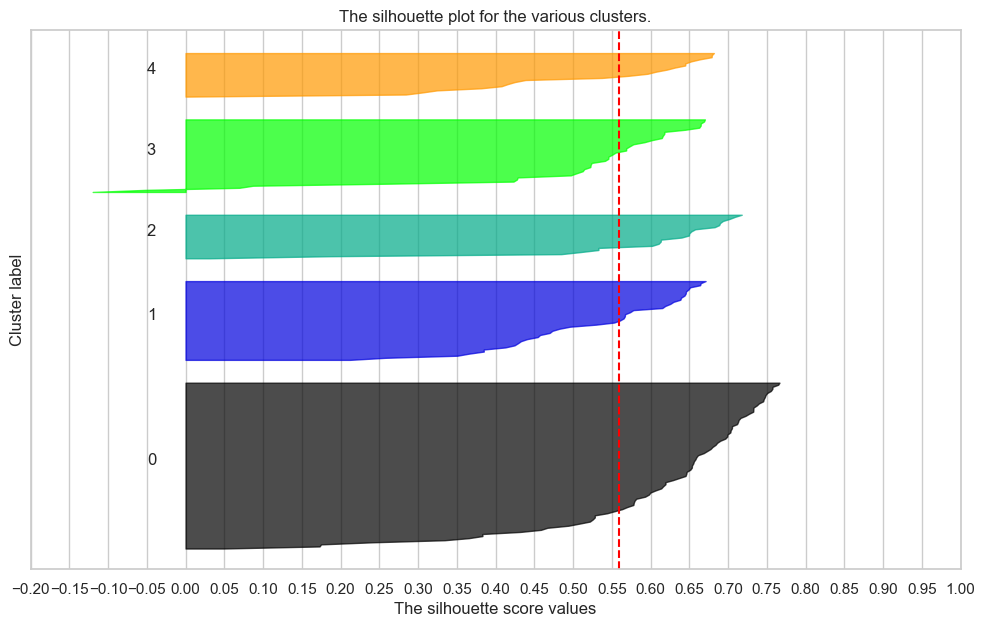

```python
import matplotlib.pyplot as plt
import matplotlib.cm as cm
import numpy as np
from sklearn.metrics import silhouette_samples, silhouette_score

# Number of clusters
n_clusters = 5

# Create a subplot with 1 row and 1 column
fig, ax1 = plt.subplots(1, 1)
fig.set_size_inches(12, 7)

# The silhouette score can range from -1, 1 but in practice, it’s between -0.1 and 1
ax1.set_xlim([-0.2, 1])
# The (n_clusters+1)*10 is for inserting blank space between silhouette plots of individual clusters
ax1.set_ylim([0, len(X_scaled) + (n_clusters + 1) * 10])

# Compute the silhouette scores for each sample
sample_silhouette_values = silhouette_samples(X_scaled, labels)
y_lower = 10
for i in range(n_clusters):
    # Aggregate the silhouette scores for samples belonging to cluster i, and sort them
    ith_cluster_silhouette_values = sample_silhouette_values[labels == i]
    ith_cluster_silhouette_values.sort()

    size_cluster_i = ith_cluster_silhouette_values.shape[0]
    y_upper = y_lower + size_cluster_i

    color = cm.nipy_spectral(float(i) / n_clusters)
    ax1.fill_betweenx(np.arange(y_lower, y_upper),
                      0, ith_cluster_silhouette_values,
                      facecolor=color, edgecolor=color, alpha=0.7)

    # Label the silhouette plots with their cluster numbers at the middle
    ax1.text(-0.05, y_lower + 0.5 * size_cluster_i, str(i))

    # Compute the new y_lower for the next plot
    y_lower = y_upper + 10  # 10 for the 0 samples

ax1.set_title("The silhouette plot for the various clusters.")
ax1.set_xlabel("The silhouette score values")
ax1.set_ylabel("Cluster label")

# The vertical line for average silhouette score of all the values
ax1.axvline(x=silhouette, color="red", linestyle="--", label=f'Average silhouette score={(silhouette)}')
ax1.set_yticks([])  # Clear the yaxis labels / ticks
ax1.set_xticks(np.arange(-0.2, 1.05, 0.05))

plt.show()
```

### Determining the Optimal Number of Clusters

Selecting the optimal number of clusters is crucial in K-Means clustering. Various metrics can be used to determine the best K value, such as within-cluster variation, between-cluster variation, and the CH index.

These metrics and methods are used to evaluate the performance and quality of clustering algorithms. Here's a brief overview of each:

### 1. Davies-Bouldin Index (DBI)

- **Purpose**: To evaluate the quality of clustering.
- **Description**: DBI measures the average similarity ratio of each cluster with the cluster that is most similar to it. It combines the concepts of cluster compactness and separation.
- **Formula**: $$ DBI = \frac{1}{n} \sum_{i=1}^{n} \max_{j \neq i} \left( \frac{\sigma_i + \sigma_j}{d_{ij}} \right) $$ where:
  - ($ n $) is the number of clusters.
  - ($ \sigma_i $) is the average distance between each point in cluster ( i ) and the centroid of cluster ( i ).
  - ($ d_{ij} $) is the distance between the centroids of clusters ( i ) and ( j ).
- **Interpretation**: Lower DBI values indicate better clustering. It means that clusters are compact and well-separated.

### 2. Calinski-Harabasz Index (CHI)

- **Purpose**: To evaluate the quality of clustering.
- **Description**: CHI, also known as the Variance Ratio Criterion, measures the ratio of the sum of between-cluster dispersion to the sum of within-cluster dispersion.
- **Formula**: $$ CHI = \frac{(SSB / (k - 1))}{(SSW / (n - k))} $$ where:
  - ($ SSB $) is the between-cluster dispersion.
  - ($ SSW $) is the within-cluster dispersion.
  - ($ k $) is the number of clusters.
  - ($ n $) is the number of data points.
- **Interpretation**: Higher CHI values indicate better-defined clusters.

### 3. Within-Cluster Sum of Squares (WCSS)

- **Purpose**: To measure the total variance within clusters.
- **Description**: WCSS is the sum of squared distances between each data point and the centroid of its assigned cluster. It quantifies the compactness of the clusters.
- **Formula**: $$ WCSS = \sum_{i=1}^{k} \sum_{x \in C_i} (x - \mu_i)^2 $$ where:
  - ($ k $) is the number of clusters.
  - ($ C_i $) is the ( i )-th cluster.
  - ($ \mu_i $) is the centroid of the ( i )-th cluster.
  - ($ x $) is a data point.
- **Interpretation**: Lower WCSS values indicate more compact clusters.

### 4. Elbow Method

- **Purpose**: To determine the optimal number of clusters for K-Means clustering.
- **Description**: The Elbow Method involves plotting WCSS against the number of clusters. The goal is to find the "elbow point" where the rate of decrease in WCSS slows down significantly.
- **Process**:
  1. Run K-Means clustering for a range of ($ k $) values (number of clusters).
  2. Calculate WCSS for each ($ k $).
  3. Plot WCSS against ($ k $).
  4. Identify the "elbow point" where adding more clusters does not significantly reduce WCSS.
- **Interpretation**: The optimal number of clusters is at the elbow point, balancing compactness and computational efficiency.

### Summary

- **DBI**: Evaluates cluster compactness and separation. Lower values are better.
- **CHI**: Measures the ratio of between-cluster dispersion to within-cluster dispersion. Higher values are better.
- **WCSS**: Measures the total variance within clusters. Lower values are better.
- **Elbow Method**: Helps determine the optimal number of clusters by finding the point where adding more clusters does not significantly reduce WCSS.

#### Elbow Method

The Elbow Method is a commonly used technique to identify the optimal number of clusters. This method involves plotting the within-cluster sum of squares (WCSS) against the number of clusters (K). The WCSS measures the sum of the squared distances between each point and its assigned centroid. The goal is to find the point where the addition of another cluster does not significantly improve the model, indicating the optimal number of clusters.

Let's implement the Elbow Method:

```
from sklearn.cluster import KMeans
import matplotlib.pyplot as plt

# Calculate WCSS for different number of clusters
wcss = []
for i in range(1, 11):
    kmeans = KMeans(n_clusters=i, random_state=42)
    kmeans.fit(X_scaled)
    wcss.append(kmeans.inertia_)

# Plot the Elbow Method graph
plt.figure(figsize=(10, 6))
plt.plot(range(1, 11), wcss, marker='o', c='green')
plt.title('Elbow Method for Determining Optimal Clusters', fontsize=16)
plt.xlabel('Number of Clusters', fontsize=14)
plt.ylabel('WCSS', fontsize=14)
plt.grid(True)
plt.show()
```

### Visualization Using Plotly

To create a more interactive and professional visualization, let's use Plotly for the Elbow Method graph.

```
import plotly.graph_objects as go

fig = go.Figure()

fig.add_trace(go.Scatter(
    x=list(range(1, 11)),
    y=wcss,
    mode='lines+markers',
    marker=dict(color='Orange'', size=10),
    line=dict(color='RoyalBlue', width=2),
    name='WCSS'
))

fig.update_layout(
    title='Elbow Method for Determining Optimal Clusters',
    xaxis=dict(title='Number of Clusters'),
    yaxis=dict(title='WCSS'),
    template='plotly_white'
)

fig.show()
```

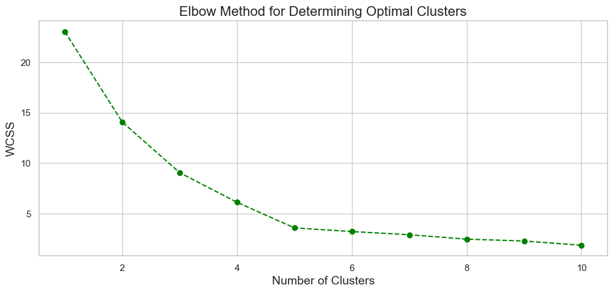

```python
from sklearn.cluster import KMeans
import matplotlib.pyplot as plt
import plotly.graph_objects as go

# Calculate WCSS for different number of clusters
wcss = []
for i in range(1, 11):
    kmeans = KMeans(n_clusters=i, random_state=42)
    kmeans.fit(X_scaled)
    wcss.append(kmeans.inertia_)

# Plot the Elbow Method graph
plt.figure(figsize=(12, 5))
plt.plot(range(1, 11), wcss, marker='o', linestyle='--', c='green')
plt.title('Elbow Method for Determining Optimal Clusters', fontsize=16)
plt.xlabel('Number of Clusters', fontsize=14)
plt.ylabel('WCSS', fontsize=14)
plt.grid(True)
plt.show()

# Plotly
fig = go.Figure()

fig.add_trace(go.Scatter(
    x=list(range(1, 11)),
    y=wcss,
    mode='lines+markers',
    marker=dict(color='Orange', size=10),
    line=dict(color='RoyalBlue', width=2),
    name='WCSS'
))

fig.update_layout(
    title='Elbow Method for Determining Optimal Clusters',
    xaxis=dict(title='Number of Clusters'),
    yaxis=dict(title='WCSS'),
    template='plotly_dark'
)

fig.show()
```

### Explanation of the Code:

1. **Compute the Silhouette Scores**:

   ```
   sample_silhouette_values = silhouette_samples(X_scaled, labels)
   ```

   This computes the silhouette score for each sample in the dataset, which is necessary for plotting the silhouette diagram.
2. **Plot the Silhouette Scores**:

   ```
   for i in range(n_clusters):
       ith_cluster_silhouette_values = sample_silhouette_values[labels == i]
       ith_cluster_silhouette_values.sort()

       size_cluster_i = ith_cluster_silhouette_values.shape[0]
       y_upper = y_lower + size_cluster_i

       color = cm.nipy_spectral(float(i) / n_clusters)
       ax1.fill_betweenx(np.arange(y_lower, y_upper),
                         0, ith_cluster_silhouette_values,
                         facecolor=color, edgecolor=color, alpha=0.7)

       ax1.text(-0.05, y_lower + 0.5 * size_cluster_i, str(i))
       y_lower = y_upper + 10
   ```

   This loop iterates over each cluster, sorts the silhouette values for samples in that cluster, and then fills the silhouette plot for that cluster. The silhouette plot is colored differently for each cluster to make it visually distinct.
3. **Vertical Line for Average Silhouette Score**:

   ```
   ax1.axvline(x=silhouette, color="red", linestyle="--")
   ```

   This adds a vertical line indicating the average silhouette score across all samples, providing a reference point for the overall quality of the clustering.

### Inference from the Elbow Method

The Elbow Method graph plots the number of clusters against the WCSS. The optimal number of clusters is identified at the "elbow" point of the graph where the WCSS starts to decrease more slowly. This point represents the trade-off between the number of clusters and the amount of variance explained by the clusters.

- If the WCSS continues to decrease sharply as more clusters are added, this indicates that each additional cluster significantly improves the model.
- If the WCSS starts to level off, this suggests that adding more clusters does not significantly improve the model.

**Insight**: The `Elbow Method` helps identify the optimal number of clusters by showing where the addition of another cluster does not significantly reduce the WCSS. The "elbow" point in the graph indicates the optimal number of clusters, which in this case, we observe to be around `5 clusters`.

## Evaluating a Range of K Clusters for K-Means

```
Silhouette Score for k=2: 0.3447138642257591
Silhouette Score for k=3: 0.4498539603795658
Silhouette Score for k=4: 0.4971506623868143
Silhouette Score for k=5: 0.5593469429051445
Silhouette Score for k=6: 0.5244046259750482
Silhouette Score for k=7: 0.48083628842905113
Silhouette Score for k=8: 0.47423530152553683
Silhouette Score for k=9: 0.4332042575649034
Silhouette Score for k=10: 0.44833378088523645
```

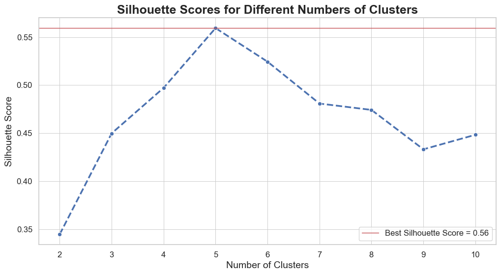

```python
import matplotlib.pyplot as plt
import seaborn as sns
from sklearn.cluster import KMeans
from sklearn.metrics import silhouette_score

# Set the style
sns.set(style="whitegrid")

# Evaluate silhouette scores for a range of clusters
silhouette_scores = []
for i in range(2, 11):
    kmeans = KMeans(n_clusters=i, random_state=42)
    kmeans.fit(X_scaled)
    score = silhouette_score(X_scaled, kmeans.labels_)
    silhouette_scores.append(score)
    print(f'Silhouette Score for k={i}: {score}')

# Plot Silhouette Scores
plt.figure(figsize=(12, 6))
sns.lineplot(x=range(2, 11), y=silhouette_scores, marker='o', linestyle='--', color='b', linewidth=2.5)
plt.title('Silhouette Scores for Different Numbers of Clusters', fontsize=18, weight='bold')
plt.xlabel('Number of Clusters', fontsize=14)
plt.ylabel('Silhouette Score', fontsize=14)
plt.xticks(range(2, 11), fontsize=12)
plt.yticks(fontsize=12)
plt.grid(True,linestyle='-', linewidth=0.7)
plt.axhline(y=max(silhouette_scores), color='r', linestyle='-', linewidth=1, label=f'Best Silhouette Score = {max(silhouette_scores):.2f}')
plt.legend(fontsize=12)
plt.show()
```

### Explanation of Code:

1. **Setting the Style**:

   ```
   sns.set(style="whitegrid")
   ```

   Using Seaborn's whitegrid style provides a clean background with grid lines, making the plot easier to read.
2. **Enhanced Plot Design**:

   ```
   plt.figure(figsize=(12, 8))
   sns.lineplot(x=range(2, 11), y=silhouette_scores, marker='o', linestyle='--', color='b', linewidth=2.5)
   ```

   - **Figure Size**: A larger figure size ensures better visibility of the plot.
   - **Line Plot**: Using Seaborn's `lineplot` function for a smoother and more aesthetically pleasing line plot.
3. **Plot Customization**:

   ```
   plt.title('Silhouette Scores for Different Numbers of Clusters', fontsize=18, weight='bold')
   plt.xlabel('Number of Clusters', fontsize=14)
   plt.ylabel('Silhouette Score', fontsize=14)
   plt.xticks(range(2, 11), fontsize=12)
   plt.yticks(fontsize=12)
   plt.grid(True, linestyle='--', linewidth=0.5)
   plt.axhline(y=max(silhouette_scores), color='r', linestyle='-', linewidth=1, label=f'Best Silhouette Score = {max(silhouette_scores):.2f}')
   plt.legend(fontsize=12)
   ```

   - **Title and Labels**: Adding a bold title and larger font sizes for the axis labels for better readability.
   - **Ticks**: Adjusting font sizes of the ticks for a professional look.
   - **Grid Lines**: Customizing the grid lines for a cleaner appearance.
   - **Highlighting Best Score**: Adding a horizontal line to highlight the best silhouette score.

### Inference from Silhouette Score

**Answer**: A silhouette score close to 1 indicates well-clustered points. The score of `0.559` suggests reasonable clustering, as it is greater than 0 and closer to 1 than to -1, indicating some degree of separation and cohesion within the clusters.

### Interpreting the Silhouette Score

The silhouette score provides a measure of how well each point lies within its cluster compared to points in other clusters. Here's how to interpret the score:

- **Silhouette Score close to +1**: Indicates that the data points are well-clustered and are well-separated from other clusters.
- **Silhouette Score around 0**: Suggests that the data points are on or very close to the decision boundary between two neighboring clusters.
- **Silhouette Score close to -1**: Indicates that the data points might have been assigned to the wrong cluster.

**Interpretation for our K-Means Model**:

- **`Score of 0.559`**: This score suggests that the points are reasonably well-clustered, with some degree of separation between clusters. While it is not close to 1, indicating perfect clustering, it is still significantly greater than 0, showing that the clustering algorithm has performed adequately in creating distinct clusters.

The silhouette score helps us understand the cohesion and separation of the clusters formed. Although the score of `0.559` is not exceptionally high, it indicates that the clustering quality is moderate, and the clusters are reasonably well-defined.

By using the silhouette score in conjunction with the Elbow Method, we can make a more informed decision about the optimal number of clusters and the overall quality of the clustering process. This combination of methods provides a robust approach to evaluating and improving clustering models.

### Clustering with Calinski-Harabasz Index

The Calinski-Harabasz Index (CH Index) is another metric used to evaluate the quality of clustering. A higher CH Index indicates better-defined clusters.

Let's calculate the CH Index for K-Means clustering with different numbers of clusters.

```
from sklearn.metrics import calinski_harabasz_score
import matplotlib.pyplot as plt
import seaborn as sns

# Calculate CH Scores for different number of clusters
ch_scores = []
for i in range(2, 11):
    kmeans = KMeans(n_clusters=i, random_state=42)
    kmeans.fit(X_scaled)
    score = calinski_harabasz_score(X_scaled, kmeans.labels_)
    ch_scores.append(score)

# Plot CH Scores
plt.figure(figsize=(12, 8))
sns.lineplot(x=range(2, 11), y=ch_scores, marker='o', linestyle='--', color='b', linewidth=2.5)
plt.title('Calinski-Harabasz Scores for Different Numbers of Clusters', fontsize=18, weight='bold')
plt.xlabel('Number of Clusters', fontsize=14)
plt.ylabel('CH Index', fontsize=14)
plt.xticks(range(2, 11), fontsize=12)
plt.yticks(fontsize=12)
plt.grid(True, linestyle='-', linewidth=0.9)
plt.axhline(y=max(ch_scores), color='r', linestyle='-', linewidth=2, label=f'Best CH Index = {max(ch_scores):.2f}')
plt.legend(fontsize=12)
plt.show()
```

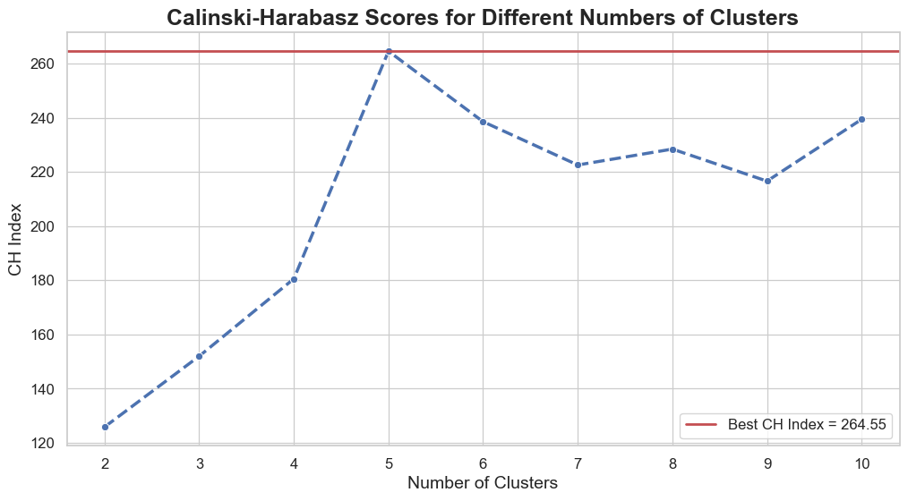

```python
from sklearn.metrics import calinski_harabasz_score
import matplotlib.pyplot as plt
import seaborn as sns

# Calculate CH Scores for different number of clusters
ch_scores = []
for i in range(2, 11):
    kmeans = KMeans(n_clusters=i, random_state=42)
    kmeans.fit(X_scaled)
    score = calinski_harabasz_score(X_scaled, kmeans.labels_)
    ch_scores.append(score)

# Plot CH Scores
plt.figure(figsize=(12, 6))
sns.lineplot(x=range(2, 11), y=ch_scores, marker='o', linestyle='--', color='b', linewidth=2.5)
plt.title('Calinski-Harabasz Scores for Different Numbers of Clusters', fontsize=18, weight='bold')
plt.xlabel('Number of Clusters', fontsize=14)
plt.ylabel('CH Index', fontsize=14)
plt.xticks(range(2, 11), fontsize=12)
plt.yticks(fontsize=12)
plt.grid(True, linestyle='-', linewidth=0.9)
plt.axhline(y=max(ch_scores), color='r', linestyle='-', linewidth=2, label=f'Best CH Index = {max(ch_scores):.2f}')
plt.legend(fontsize=12)
plt.show()
```

### Explanation of the Code

#### Importing Necessary Libraries

We import `calinski_harabasz_score` from `sklearn.metrics` to calculate the Calinski-Harabasz Index for evaluating clustering performance. We also import `matplotlib.pyplot` and `seaborn` for creating and enhancing our plots.

#### Calculating CH Scores for Different Numbers of Clusters

```
ch_scores = []
for i in range(2, 11):
    kmeans = KMeans(n_clusters=i, random_state=42)
    kmeans.fit(X_scaled)
    score = calinski_harabasz_score(X_scaled, kmeans.labels_)
    ch_scores.append(score)
```

- **ch_scores**: An empty list to store the Calinski-Harabasz scores for different cluster numbers.
- **Loop from 2 to 10**: We iterate over a range of cluster numbers from 2 to 10.
  - **KMeans Initialization**: For each iteration, we initialize the KMeans algorithm with `i` clusters.
  - **Fit the Model**: Fit the KMeans model to the scaled data `X_scaled`.
  - **Calculate CH Index**: Calculate the Calinski-Harabasz score using the `calinski_harabasz_score` function, which evaluates the model based on the ratio of the sum of between-cluster dispersion and within-cluster dispersion for all clusters.
  - **Append the Score**: Append the calculated score to the `ch_scores` list.

#### Plotting CH Scores

```
plt.figure(figsize=(12, 8))
sns.lineplot(x=range(2, 11), y=ch_scores, marker='o', linestyle='--', color='b', linewidth=2.5)
plt.title('Calinski-Harabasz Scores for Different Numbers of Clusters', fontsize=18, weight='bold')
plt.xlabel('Number of Clusters', fontsize=14)
plt.ylabel('CH Index', fontsize=14)
plt.xticks(range(2, 11), fontsize=12)
plt.yticks(fontsize=12)
plt.grid(True, linestyle='--', linewidth=0.5)
plt.axhline(y=max(ch_scores), color='r', linestyle='-', linewidth=2, label=f'Best CH Index = {max(ch_scores):.2f}')
plt.legend(fontsize=12)
plt.show()
```

### Insights from Calinski-Harabasz Index

The plot of Calinski-Harabasz scores helps in identifying the optimal number of clusters for K-Means clustering.

### Use Case

By using both the Silhouette Score and the Calinski-Harabasz Index, we can make more informed decisions about the optimal number of clusters for our dataset. These metrics provide complementary insights into the clustering quality, helping to achieve better-defined and meaningful clusters.

**Visualized CH Index Plot**:

[figure not shown]

### Understanding Quality of Clustering through Davies-Bouldin Index

The Davies-Bouldin Index (DBI) is a crucial metric for evaluating the quality of clustering. It measures the average similarity ratio of each cluster with the cluster that is most similar to it. In simpler terms, DBI provides a measure of how well the clusters are separated from each other and how compact they are within themselves.

- **Compactness**: A cluster is considered compact if the data points within it are close to each other.
- **Separation**: Clusters are well-separated if the distance between clusters is large compared to the diameter of the clusters.

#### Formula

The DBI is calculated as follows:

$$ DBI = \frac{1}{n} \sum_{i=1}^{n} \max_{j \neq i} \left( \frac{\sigma_i + \sigma_j}{d_{ij}} \right) $$

where:

- $n$ is the number of clusters.
- $\sigma_i$ is the average distance between each point in cluster $i$ and the centroid of cluster $i$.
- $d_{ij}$ is the distance between the centroids of clusters $i$ and $j$.

**`Rendering the Math symbols uses LaTeX library in Python`**

### Interpreting the Davies-Bouldin Index

The interpretation of a DBI value depends on the context and the specific dataset. However, there are some general guidelines:

- **DBI < 1**: Indicates good clustering, with compact and well-separated clusters.
- **DBI around 1 to 2**: Indicates fair clustering, with moderate compactness and separation.
- **DBI > 2**: Indicates poor clustering, with less compact and poorly separated clusters.

A lower DBI indicates that the clusters are compact and well-separated, which is desirable in clustering.

```python
from sklearn.metrics import davies_bouldin_score

# Calculate the Davies-Bouldin Index
dbi = davies_bouldin_score(X_scaled, labels)
print(f'Davies-Bouldin Index value is: {dbi}')
```

```
Davies-Bouldin Index value is: 0.5616471225010365
```

### Types of Hierarchical Clustering Algorithms

Hierarchical clustering algorithms build a hierarchy of clusters by either iteratively merging smaller clusters (agglomerative) or splitting larger clusters (divisive). There are two primary types of hierarchical clustering algorithms:

#### 1. Agglomerative Clustering (Bottom-Up Approach)

Agglomerative clustering, also known as bottom-up clustering, starts with each data point as its own cluster. It then iteratively merges the closest pairs of clusters until all points are contained in a single cluster or a specified number of clusters is reached.

**Steps in Agglomerative Clustering**:

1. **Initialization**: Start with each data point as a single cluster.
2. **Merge Clusters**: At each step, merge the two clusters that are closest to each other based on a chosen linkage criterion.
3. **Repeat**: Continue merging until the desired number of clusters is achieved or all points are in a single cluster.

**Advantages**:

- Does not require the number of clusters to be specified in advance.
- Can produce an entire hierarchy of clusters.

**Disadvantages**:

- Computationally intensive for large datasets.
- Sensitive to noise and outliers.

#### 2. Divisive Clustering (Top-Down Approach)

Divisive clustering, also known as top-down clustering, starts with all data points in a single cluster. It then iteratively splits the most dissimilar clusters until each point is in its own cluster or the desired number of clusters is achieved.

**Steps in Divisive Clustering**:

1. **Initialization**: Start with all data points in a single cluster.
2. **Split Clusters**: At each step, split the cluster that has the highest dissimilarity within it based on a chosen criterion.
3. **Repeat**: Continue splitting until the desired number of clusters is achieved or each point is in its own cluster.

**Advantages**:

- Can provide a global view of the clustering structure.
- Useful for identifying outliers.

**Disadvantages**:

- Computationally more intensive than agglomerative clustering.
- Less commonly used in practice.

### Practical Implementation of Agglomerative Clustering

Hierarchical clustering methods, such as Agglomerative Clustering, build a hierarchy of clusters by successively merging or splitting them. This method can reveal the underlying structure of the data, especially when the clusters are not well-separated.

Agglomerative Clustering starts with each data point as its own cluster and then merges the closest pairs of clusters iteratively until only the desired number of clusters remains.

#### Code for Agglomerative Clustering

```
from sklearn.cluster import AgglomerativeClustering
import matplotlib.pyplot as plt
import seaborn as sns

# Initialize the AgglomerativeClustering model
cluster = AgglomerativeClustering(n_clusters=5, linkage='ward')

# Fit the model and predict the cluster labels
labels = cluster.fit_predict(X_scaled)
print(labels)

# Add the cluster labels to the original data
data['Cluster'] = labels

# Plotting the clusters
plt.figure(figsize=(12, 8))
sns.scatterplot(x=data['Annual_Income_(k$)'], y=data['Spending_Score'], hue=data['Cluster'], palette='viridis', s=100)
plt.title('Clusters of Customers - Agglomerative Clustering', fontsize=18, weight='bold')
plt.xlabel('Annual Income (k$)', fontsize=14)
plt.ylabel('Spending Score', fontsize=14)
plt.legend(title='Cluster', fontsize=12)
plt.grid(True, linestyle='--', linewidth=0.5)
plt.show()
```

**Note**: Use `cluster.fit_predict(X_scaled)` to obtain cluster labels.

```
[4 3 4 3 4 3 4 3 4 3 4 3 4 3 4 3 4 3 4 3 4 3 4 3 4 3 4 1 4 3 4 3 4 3 4 3 4
 3 4 3 4 3 4 1 4 1 1 1 1 1 1 1 1 1 1 1 1 1 1 1 1 1 1 1 1 1 1 1 1 1 1 1 1 1
 1 1 1 1 1 1 1 1 1 1 1 1 1 1 1 1 1 1 1 1 1 1 1 1 1 1 1 1 1 1 1 1 1 1 1 1 1
 1 1 1 1 1 1 1 1 1 1 1 1 0 1 0 1 0 2 0 2 0 1 0 2 0 2 0 2 0 2 0 1 0 2 0 1 0
 2 0 2 0 2 0 2 0 2 0 2 0 1 0 2 0 2 0 2 0 2 0 2 0 2 0 2 0 2 0 2 0 2 0 2 0 2
 0 2 0 2 0 2 0 2 0 2 0 2 0 2 0]
```

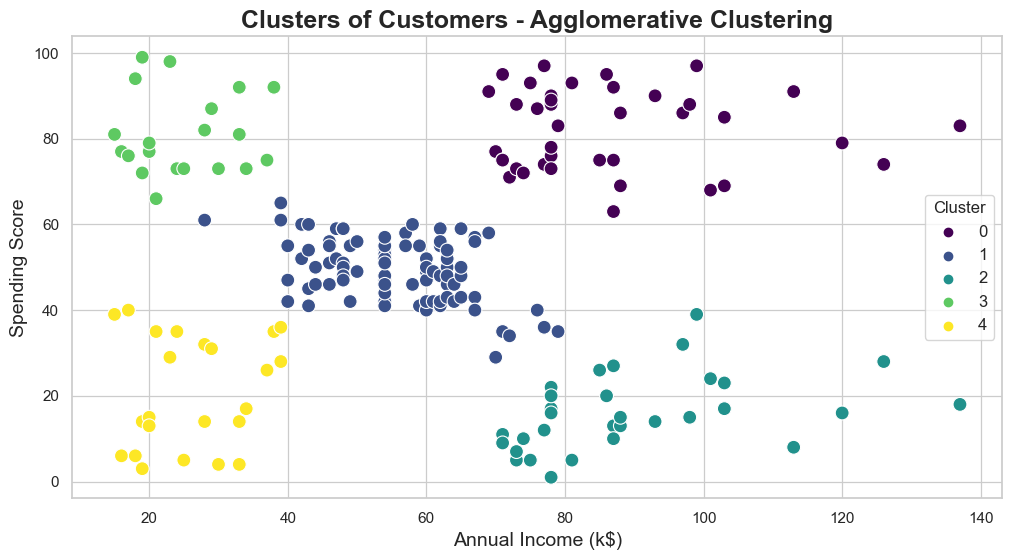

```python
from sklearn.cluster import AgglomerativeClustering
import matplotlib.pyplot as plt
import seaborn as sns

# Initialize the AgglomerativeClustering model
cluster = AgglomerativeClustering(n_clusters=5, linkage='ward')

# Fit the model and predict the cluster labels
labels = cluster.fit_predict(X_scaled)
print(labels)

# Add the cluster labels to the original data
data['Cluster'] = labels

# Plotting the clusters
plt.figure(figsize=(12, 6))
sns.scatterplot(x=data['Annual_Income_(k$)'], y=data['Spending_Score'], hue=data['Cluster'], palette='viridis', s=100)
plt.title('Clusters of Customers - Agglomerative Clustering', fontsize=18, weight='bold')
plt.xlabel('Annual Income (k$)', fontsize=14)
plt.ylabel('Spending Score', fontsize=14)
plt.legend(title='Cluster', fontsize=12)
plt.grid(True, linestyle='-', linewidth=0.9)
plt.show()
```

### Explanation of the Code

1. **Importing Necessary Libraries**:

   ```
   from sklearn.cluster import AgglomerativeClustering
   import matplotlib.pyplot as plt
   import seaborn as sns
   ```

   We import `AgglomerativeClustering` from `sklearn.cluster` for the clustering algorithm, and `matplotlib.pyplot` and `seaborn` for visualization.
2. **Initializing the Agglomerative Clustering Model**:

   ```
   cluster = AgglomerativeClustering(n_clusters=5, linkage='ward')
   ```

   - `n_clusters=5`: Specifies the number of clusters to form.
   - `linkage='ward'`: Specifies the linkage criterion. Ward minimizes the variance of the clusters being merged, leading to more compact clusters.
3. **Fitting the Model and Predicting Cluster Labels**:

   ```
   labels = cluster.fit_predict(X_scaled)
   print(labels)
   ```

   - **fit_predict**: Fits the model and returns the cluster labels for each data point.
4. **Adding Cluster Labels to the Original Data**:

   ```
   data['Cluster'] = labels
   ```

   - Adds a new column to the original DataFrame to store the cluster labels.
5. **Plotting the Clusters**:

   ```
   plt.figure(figsize=(12, 8))
   sns.scatterplot(x=data['Annual_Income_(k$)'], y=data['Spending_Score'], hue=data['Cluster'], palette='viridis', s=100)
   plt.title('Clusters of Customers - Agglomerative Clustering', fontsize=18, weight='bold')
   plt.xlabel('Annual Income (k$)', fontsize=14)
   plt.ylabel('Spending Score', fontsize=14)
   plt.legend(title='Cluster', fontsize=12)
   plt.grid(True, linestyle='-', linewidth=0.9)
   plt.show()
   ```

### Agglomerative Clustering Summary

Agglomerative Clustering, a type of hierarchical clustering, groups data points by successively merging the closest pairs of clusters. Using 5 clusters, the algorithm assigns each data point a cluster label, indicating which cluster it belongs to.

**Cluster Labels Output**:

```
[4 3 4 3 4 3 4 3 4 3 4 3 4 3 4 3 4 3 4 3 4 3 4 3 4 3 4 1 4 3 4 3 4 3 4 3 4
 3 4 3 4 3 4 1 4 1 1 1 1 1 1 1 1 1 1 1 1 1 1 1 1 1 1 1 1 1 1 1 1 1 1 1 1 1
 1 1 1 1 1 1 1 1 1 1 1 1 1 1 1 1 1 1 1 1 1 1 1 1 1 1 1 1 1 1 1 1 1 1 1 1 1
 1 1 1 1 1 1 1 1 1 1 1 1 0 1 0 1 0 2 0 2 0 1 0 2 0 2 0 2 0 2 0 1 0 2 0 1 0
 2 0 2 0 2 0 2 0 2 0 2 0 1 0 2 0 2 0 2 0 2 0 2 0 2 0 2 0 2 0 2 0 2 0 2 0 2
 0 2 0 2 0 2 0 2 0 2 0 2 0 2 0]
```

**Summary**:

- Agglomerative Clustering provides a hierarchical approach to clustering, helping to identify natural groupings within the data. The output shows the cluster labels assigned to each data point, indicating their membership in one of the `5` clusters. This method is particularly useful when the number of clusters is not known beforehand, as it can reveal the inherent structure of the data through the hierarchical merging process.
- The plot shows distinct clusters of customers based on their annual income and spending score, which can be used for targeted marketing strategies and customer segmentation.

### Types of Linkage Criteria in Agglomerative Clustering.

Hierarchical clustering methods, such as Agglomerative Clustering, can use different linkage criteria to determine how distances between clusters are calculated. These linkage criteria significantly impact the shape and structure of the resulting clusters. Here are the main types of linkage criteria used in hierarchical clustering:

#### 1. Single Linkage (Minimum Linkage)

Single linkage, also known as minimum linkage, measures the shortest distance between any two points in the two clusters being merged. This method tends to create long, chain-like clusters and is sensitive to noise and outliers.

- **Advantages**: Can handle non-elliptical shapes and is relatively simple to implement.
- **Disadvantages**: Prone to forming elongated, less compact clusters and sensitive to outliers.

#### 2. Complete Linkage (Maximum Linkage)

Complete linkage, or maximum linkage, measures the maximum distance between any two points in the two clusters being merged. This method tends to create more compact, spherical clusters.

- **Advantages**: Produces well-separated and compact clusters.
- **Disadvantages**: Can be overly sensitive to noise and outliers, leading to smaller, tighter clusters.

#### 3. Average Linkage

Average linkage calculates the average distance between all pairs of points in the two clusters being merged. This method provides a balance between single and complete linkage, often resulting in more balanced clusters.

- **Advantages**: Balances the compactness of clusters and the separation between them.
- **Disadvantages**: Computationally intensive as it requires calculating all pairwise distances.

#### 4. Ward's Linkage

Ward's linkage minimizes the variance within clusters when merging them. This method is effective in creating clusters with small variance and is one of the most popular linkage criteria.

- **Advantages**: Produces clusters with minimum variance, often leading to more interpretable clusters.
- **Disadvantages**: Computationally intensive and assumes spherical clusters.

### Implementation of Different Linkage Criteria

Let's see how different linkage criteria can be implemented using `Agglomerative Clustering`:

```
from sklearn.cluster import AgglomerativeClustering
from sklearn.metrics import silhouette_score
import matplotlib.pyplot as plt

# Dictionary to store silhouette scores for different linkage methods
linkage_scores = {}

# Evaluate Agglomerative Clustering with different linkage methods
for linkage in ['ward', 'complete', 'average', 'single']:
    agglo = AgglomerativeClustering(n_clusters=5, linkage=linkage)
    agglo_labels = agglo.fit_predict(X_scaled)
    silhouette_avg = silhouette_score(X_scaled, agglo_labels)
    linkage_scores[linkage] = silhouette_avg
    print(f'Agglomerative Clustering with {linkage} linkage: Silhouette Score = {silhouette_avg}')

# Plot the silhouette scores for different linkage methods
plt.figure(figsize=(10, 6))
plt.bar(linkage_scores.keys(), linkage_scores.values(), color='skyblue')
plt.title('Silhouette Scores for Different Linkage Methods', fontsize=16)
plt.xlabel('Linkage Method', fontsize=14)
plt.ylabel('Silhouette Score', fontsize=14)
plt.grid(True, linestyle='-', linewidth=0.9)
plt.show()
```

```
Agglomerative Clustering with ward linkage: Silhouette Score = 0.5582698727196419
Agglomerative Clustering with complete linkage: Silhouette Score = 0.5418578306869118
Agglomerative Clustering with average linkage: Silhouette Score = 0.5565340544002426
Agglomerative Clustering with single linkage: Silhouette Score = 0.2716574259609395
```

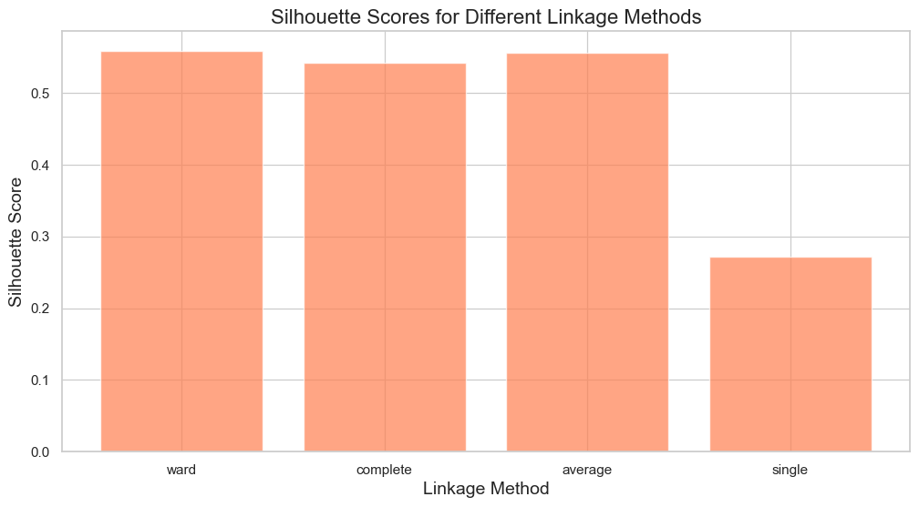

```python
from sklearn.cluster import AgglomerativeClustering
from sklearn.metrics import silhouette_score
import matplotlib.pyplot as plt

# Dictionary to store silhouette scores for different linkage methods
linkage_scores = {}

# Evaluate Agglomerative Clustering with different linkage methods
for linkage in ['ward', 'complete', 'average', 'single']:
    agglo = AgglomerativeClustering(n_clusters=5, linkage=linkage)
    agglo_labels = agglo.fit_predict(X_scaled)
    silhouette_avg = silhouette_score(X_scaled, agglo_labels)
    linkage_scores[linkage] = silhouette_avg
    print(f'Agglomerative Clustering with {linkage} linkage: Silhouette Score = {silhouette_avg}')

# Plot the silhouette scores for different linkage methods
plt.figure(figsize=(12, 6))
plt.bar(linkage_scores.keys(), linkage_scores.values(), color='coral', alpha = 0.7)
plt.title('Silhouette Scores for Different Linkage Methods', fontsize=16)
plt.xlabel('Linkage Method', fontsize=14)
plt.ylabel('Silhouette Score', fontsize=14)
plt.grid(True, linestyle='-', linewidth=0.9)
plt.show()
```

### Insights from Linkage Criteria

The choice of linkage criteria can significantly impact the clustering results:

- **Ward's Linkage**: Often provides the best clustering quality by minimizing within-cluster variance, resulting in more compact and interpretable clusters.
- **Average Linkage**: Offers a good balance between cluster compactness and separation, suitable for datasets with moderate noise.
- **Complete Linkage**: Tends to produce well-separated, compact clusters but can be sensitive to outliers.
- **Single Linkage**: Can handle non-elliptical clusters and works well with non-spherical shapes but is prone to forming elongated clusters and is sensitive to noise.

By experimenting with different linkage criteria, you can select the most suitable method for your specific dataset, ensuring better-defined and meaningful clusters.

### Evaluating Different Clustering Algorithms

If the silhouette score is unsatisfactory, we need to consider several next steps to improve the clustering performance:

1. **Adjusting the Number of Clusters**: Experiment with different numbers of clusters (k) to find the optimal number that maximizes the silhouette score.
2. **Exploring Other Clustering Algorithms**: Use alternative clustering algorithms such as Hierarchical Clustering, DBSCAN, or Gaussian Mixture Models to see if they yield better results.
3. **Enriching the Dataset**: Add more relevant features to the dataset to provide more information to the clustering algorithm, which might help in forming better-defined clusters.

```
from sklearn.cluster import KMeans, AgglomerativeClustering, DBSCAN
from sklearn.metrics import silhouette_score
from sklearn.mixture import GaussianMixture
import matplotlib.pyplot as plt
import seaborn as sns

# Store silhouette scores
silhouette_scores = {}

# KMeans with different number of clusters
kmeans_silhouettes = []
for k in range(2, 11):
    kmeans = KMeans(n_clusters=k, random_state=42)
    kmeans.fit(X_scaled)
    kmeans_labels = kmeans.predict(X_scaled)
    kmeans_silhouette = silhouette_score(X_scaled, kmeans_labels)
    kmeans_silhouettes.append(kmeans_silhouette)
    print(f'KMeans with {k} clusters: Silhouette Score = {kmeans_silhouette}')
silhouette_scores['KMeans'] = kmeans_silhouettes

# Agglomerative Clustering with different linkage methods
agglo_silhouettes = []
linkages = ['ward', 'complete', 'average', 'single']
for linkage in linkages:
    agglo = AgglomerativeClustering(n_clusters=5, linkage=linkage)
    agglo_labels = agglo.fit_predict(X_scaled)
    agglo_silhouette = silhouette_score(X_scaled, agglo_labels)
    agglo_silhouettes.append(agglo_silhouette)
    print(f'Agglomerative Clustering with {linkage} linkage: Silhouette Score = {agglo_silhouette}')
silhouette_scores['Agglomerative'] = agglo_silhouettes

# DBSCAN
dbscan = DBSCAN(eps=0.2, min_samples=10)
dbscan_clusters = dbscan.fit_predict(X_scaled)
# Handle case where DBSCAN finds only one cluster
if len(set(dbscan_clusters)) > 1:
    dbscan_score = silhouette_score(X_scaled, dbscan_clusters)
    silhouette_scores['DBSCAN'] = dbscan_score
    print(f'DBSCAN Silhouette Score: {dbscan_score}')
else:
    silhouette_scores['DBSCAN'] = 'N/A'
    print('DBSCAN did not find more than one cluster.')

# Gaussian Mixture Model
gmm = GaussianMixture(n_components=5, random_state=42)
gmm_clusters = gmm.fit_predict(X_scaled)
gmm_score = silhouette_score(X_scaled, gmm_clusters)
silhouette_scores['GMM'] = gmm_score
print(f'Gaussian Mixture Model Silhouette Score: {gmm_score}')

# Plotting the Silhouette Scores
plt.figure(figsize=(14, 8))

# Plot for KMeans
kmeans_x = list(range(2, 11))
sns.lineplot(x=kmeans_x, y=silhouette_scores['KMeans'], marker='o', linestyle='--', label=f'KMeans = {max(silhouette_scores["KMeans"]):.2f}')

# Plot for Agglomerative Clustering
agglo_x = list(range(11, 15))
sns.lineplot(x=agglo_x, y=silhouette_scores['Agglomerative'], marker='o', linestyle='--', label=f'Agglomerative = {max(silhouette_scores["Agglomerative"]):.2f}')

# Combine x-ticks for both KMeans and Agglomerative Clustering
x_ticks = kmeans_x + agglo_x
x_labels = [str(i) for i in range(2, 11)] + linkages

# Add horizontal lines for DBSCAN and GMM
if silhouette_scores['DBSCAN'] != 'N/A':
    plt.axhline(y=silhouette_scores['DBSCAN'], color='r', linestyle='-', linewidth=2, label=f'DBSCAN = {silhouette_scores["DBSCAN"]:.2f}')
plt.axhline(y=silhouette_scores['GMM'], color='g', linestyle='-', linewidth=2, label=f'GMM = {silhouette_scores["GMM"]:.2f}')

plt.title('Silhouette Scores for Different Clustering Methods', fontsize=18, weight='bold')
plt.xlabel('Number of Clusters or Linkage Method', fontsize=14)
plt.ylabel('Silhouette Score', fontsize=14)
plt.xticks(ticks=x_ticks, labels=x_labels, fontsize=14, rotation=0)
plt.legend(fontsize=14)
plt.grid(True, linestyle='-', linewidth=0.9)
plt.tight_layout()  # Adjust layout to prevent overlapping
plt.show()
```

```
KMeans with 2 clusters: Silhouette Score = 0.3447138642257591
KMeans with 3 clusters: Silhouette Score = 0.4498539603795658
KMeans with 4 clusters: Silhouette Score = 0.4971506623868143
KMeans with 5 clusters: Silhouette Score = 0.5593469429051445
KMeans with 6 clusters: Silhouette Score = 0.5244046259750482
KMeans with 7 clusters: Silhouette Score = 0.48083628842905113
KMeans with 8 clusters: Silhouette Score = 0.47423530152553683
KMeans with 9 clusters: Silhouette Score = 0.4332042575649034
KMeans with 10 clusters: Silhouette Score = 0.44833378088523645
Agglomerative Clustering with ward linkage: Silhouette Score = 0.5582698727196419
Agglomerative Clustering with complete linkage: Silhouette Score = 0.5418578306869118
Agglomerative Clustering with average linkage: Silhouette Score = 0.5565340544002426
Agglomerative Clustering with single linkage: Silhouette Score = 0.2716574259609395
DBSCAN Silhouette Score: 0.4239806178753844
Gaussian Mixture Model Silhouette Score: 0.5601396671322825
```

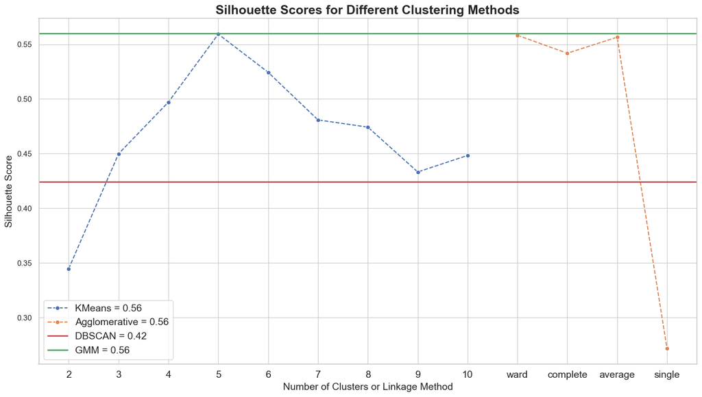

```python
from sklearn.cluster import KMeans, AgglomerativeClustering, DBSCAN
from sklearn.metrics import silhouette_score
from sklearn.mixture import GaussianMixture
import matplotlib.pyplot as plt
import seaborn as sns

# Store silhouette scores
silhouette_scores = {}

# KMeans with different number of clusters
kmeans_silhouettes = []
for k in range(2, 11):
    kmeans = KMeans(n_clusters=k, random_state=42)
    kmeans.fit(X_scaled)
    kmeans_labels = kmeans.predict(X_scaled)
    kmeans_silhouette = silhouette_score(X_scaled, kmeans_labels)
    kmeans_silhouettes.append(kmeans_silhouette)
    print(f'KMeans with {k} clusters: Silhouette Score = {kmeans_silhouette}')
silhouette_scores['KMeans'] = kmeans_silhouettes

# Agglomerative Clustering with different linkage methods
agglo_silhouettes = []
linkages = ['ward', 'complete', 'average', 'single']
for linkage in linkages:
    agglo = AgglomerativeClustering(n_clusters=5, linkage=linkage)
    agglo_labels = agglo.fit_predict(X_scaled)
    agglo_silhouette = silhouette_score(X_scaled, agglo_labels)
    agglo_silhouettes.append(agglo_silhouette)
    print(f'Agglomerative Clustering with {linkage} linkage: Silhouette Score = {agglo_silhouette}')
silhouette_scores['Agglomerative'] = agglo_silhouettes

# DBSCAN
dbscan = DBSCAN(eps=0.2, min_samples=10)
dbscan_clusters = dbscan.fit_predict(X_scaled)
# Handle case where DBSCAN finds only one cluster
if len(set(dbscan_clusters)) > 1:
    dbscan_score = silhouette_score(X_scaled, dbscan_clusters)
    silhouette_scores['DBSCAN'] = dbscan_score
    print(f'DBSCAN Silhouette Score: {dbscan_score}')
else:
    silhouette_scores['DBSCAN'] = 'N/A'
    print('DBSCAN did not find more than one cluster.')

# Gaussian Mixture Model
gmm = GaussianMixture(n_components=5, random_state=42)
gmm_clusters = gmm.fit_predict(X_scaled)
gmm_score = silhouette_score(X_scaled, gmm_clusters)
silhouette_scores['GMM'] = gmm_score
print(f'Gaussian Mixture Model Silhouette Score: {gmm_score}')

# Plotting the Silhouette Scores
plt.figure(figsize=(14, 8))

# Plot for KMeans
kmeans_x = list(range(2, 11))
sns.lineplot(x=kmeans_x, y=silhouette_scores['KMeans'], marker='o', linestyle='--', label=f'KMeans = {max(silhouette_scores["KMeans"]):.2f}')

# Plot for Agglomerative Clustering
agglo_x = list(range(11, 15))
sns.lineplot(x=agglo_x, y=silhouette_scores['Agglomerative'], marker='o', linestyle='--', label=f'Agglomerative = {max(silhouette_scores["Agglomerative"]):.2f}')

# Combine x-ticks for both KMeans and Agglomerative Clustering
x_ticks = kmeans_x + agglo_x
x_labels = [str(i) for i in range(2, 11)] + linkages

# Add horizontal lines for DBSCAN and GMM
if silhouette_scores['DBSCAN'] != 'N/A':
    plt.axhline(y=silhouette_scores['DBSCAN'], color='r', linestyle='-', linewidth=2, label=f'DBSCAN = {silhouette_scores["DBSCAN"]:.2f}')
plt.axhline(y=silhouette_scores['GMM'], color='g', linestyle='-', linewidth=2, label=f'GMM = {silhouette_scores["GMM"]:.2f}')

plt.title('Silhouette Scores for Different Clustering Methods', fontsize=18, weight='bold')
plt.xlabel('Number of Clusters or Linkage Method', fontsize=14)
plt.ylabel('Silhouette Score', fontsize=14)
plt.xticks(ticks=x_ticks, labels=x_labels, fontsize=14, rotation=0)
plt.legend(fontsize=14)
plt.grid(True, linestyle='-', linewidth=0.9)
plt.tight_layout()  # Adjust layout to prevent overlapping
plt.show()
```

### Explanation of the Code

1. **Setting Up Clustering Methods**:
   - We evaluate multiple clustering algorithms: KMeans, Agglomerative Clustering, DBSCAN, and Gaussian Mixture Model.
   - For KMeans, we test a range of cluster numbers (from 2 to 10).
   - For Agglomerative Clustering, we test different linkage methods (`ward`, `complete`, `average`, `single`).
2. **Calculating Silhouette Scores**:
   - For each clustering method, we compute the silhouette score to evaluate the clustering quality.
   - The silhouette score is a measure of how similar each point is to its own cluster compared to other clusters.
3. **Plotting Silhouette Scores**:
   - We use Seaborn to plot the silhouette scores for each clustering method.
   - For KMeans, the silhouette scores are plotted against the number of clusters.
   - For Agglomerative Clustering, the scores are plotted against different linkage methods.
   - DBSCAN and Gaussian Mixture Model scores are highlighted with horizontal lines for comparison.

### Insights from Silhouette Scores

Here are the silhouette scores for K-Means with varying numbers of clusters and Agglomerative Clustering with different linkage methods:

- **K-Means Clustering:**
  - KMeans with 2 clusters: Silhouette Score = 0.3447
  - KMeans with 3 clusters: Silhouette Score = 0.4499
  - KMeans with 4 clusters: Silhouette Score = 0.4972
  - KMeans with 5 clusters: Silhouette Score = 0.5593
  - KMeans with 6 clusters: Silhouette Score = 0.5244
  - KMeans with 7 clusters: Silhouette Score = 0.4808
  - KMeans with 8 clusters: Silhouette Score = 0.4742
  - KMeans with 9 clusters: Silhouette Score = 0.4332
  - KMeans with 10 clusters: Silhouette Score = 0.4483
- **Agglomerative Clustering:**
  - Ward linkage: Silhouette Score = 0.5583
  - Complete linkage: Silhouette Score = 0.5419
  - Average linkage: Silhouette Score = 0.5565
  - Single linkage: Silhouette Score = 0.2717
- **Other Methods:**
  - DBSCAN Silhouette Score: 0.4240
  - Gaussian Mixture Model Silhouette Score: 0.5601

### Insights

By using these silhouette scores, we can compare the clustering performance of different algorithms and choose the best one for our dataset. This comprehensive evaluation helps in making informed decisions about the optimal clustering approach.

### Differences Between K-Means and Hierarchical Clustering

K-Means and Hierarchical Clustering differ in their approach to forming clusters:

- **K-Means Clustering**: Requires the number of clusters to be specified in advance and forms clusters by minimizing the variance within each cluster.
- **Hierarchical Clustering**: Does not require the number of clusters to be predefined and builds a hierarchy of clusters by either merging or splitting them successively.

### Interpreting Dendrograms

A dendrogram helps visualize the hierarchical relationship between clusters. Let's use it to determine the optimal number of clusters.

#### Dendrogram Plot

```
import scipy.cluster.hierarchy as sch
import matplotlib.pyplot as plt

# Create the linkage matrix
linkage_matrix = sch.linkage(X_scaled, method='ward')

# Create the dendrogram plot
plt.figure(figsize=(14, 10))
dendrogram = sch.dendrogram(
    linkage_matrix,
    leaf_rotation=90.,  # Rotates the x-axis labels for better readability
    leaf_font_size=12.,  # Font size for the x-axis labels
    color_threshold=None,  # Let the dendrogram decide the optimal color threshold
    above_threshold_color='black'  # Color for the links above the threshold
)

# Automatically set the threshold to be the height at which to cut the dendrogram
max_d = 0.5 * max(linkage_matrix[:, 2])  # 50% of the max distance for a more flexible threshold
plt.axhline(y=max_d, color='r', linestyle='-', linewidth=2, label=f'Threshold = {max_d:.2f}')

plt.title('Dendrogram', fontsize=18, weight='bold')
plt.xlabel('Customers', fontsize=14)
plt.ylabel('Euclidean distances', fontsize=14)
plt.xticks(fontsize=12)
plt.yticks(fontsize=12)
plt.grid(True, linestyle='--', linewidth=0.5)
plt.legend(fontsize=12)
plt.show()
```

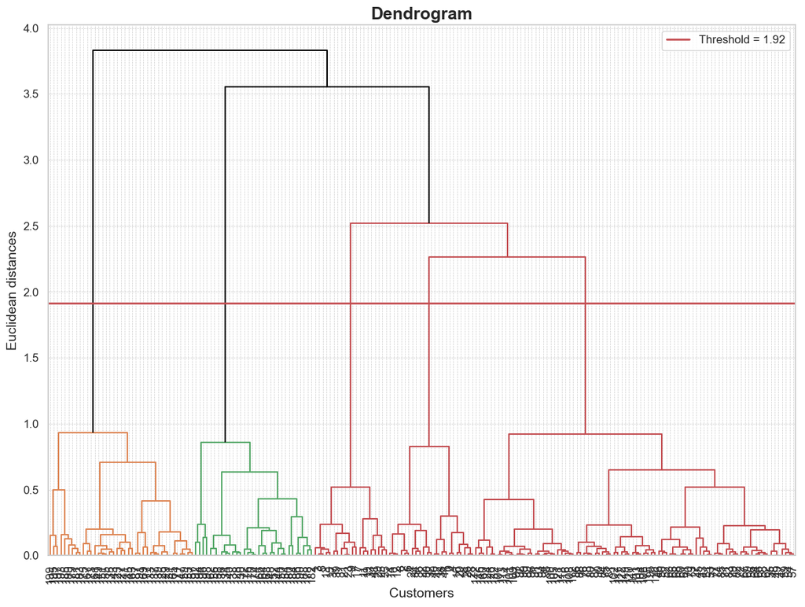

```python
import scipy.cluster.hierarchy as sch
import matplotlib.pyplot as plt

# Create the linkage matrix
linkage_matrix = sch.linkage(X_scaled, method='ward')

# Create the dendrogram plot
plt.figure(figsize=(14, 10))
dendrogram = sch.dendrogram(
    linkage_matrix,
    leaf_rotation=90.,  # Rotates the x-axis labels for better readability
    leaf_font_size=12.,  # Font size for the x-axis labels
    color_threshold=None,  # Let the dendrogram decide the optimal color threshold
    above_threshold_color='black'  # Color for the links above the threshold
)

# Automatically set the threshold to be the height at which to cut the dendrogram
max_d = 0.5 * max(linkage_matrix[:, 2])  # 50% of the max distance for a more flexible threshold
plt.axhline(y=max_d, color='r', linestyle='-', linewidth=2, label=f'Threshold = {max_d:.2f}')

plt.title('Dendrogram', fontsize=18, weight='bold')
plt.xlabel('Customers', fontsize=14)
plt.ylabel('Euclidean distances', fontsize=14)
plt.xticks(fontsize=12)
plt.yticks(fontsize=12)
plt.grid(True, linestyle='--', linewidth=0.5)
plt.legend(fontsize=12)
plt.show()
```

### Explanation of the Code:

1. **Import Libraries**:

   ```
   import scipy.cluster.hierarchy as sch
   import matplotlib.pyplot as plt
   ```

   We use `scipy.cluster.hierarchy` for hierarchical clustering and `matplotlib` for plotting.
2. **Create the Linkage Matrix**:

   ```
   linkage_matrix = sch.linkage(X_scaled, method='ward')
   ```

   We create a linkage matrix using the Ward method, which is used to build the dendrogram.
3. **Create the Dendrogram Plot**:

   ```
   plt.figure(figsize=(14, 10))
   dendrogram = sch.dendrogram(
       linkage_matrix,
       leaf_rotation=90.,  # Rotates the x-axis labels for better readability
       leaf_font_size=12.,  # Font size for the x-axis labels
       color_threshold=None,  # Let the dendrogram decide the optimal color threshold
       above_threshold_color='black'  # Color for the links above the threshold
   )
   ```

   - **Figure Size**: Set a larger figure size for better visibility.
   - **Dendrogram Parameters**: Customize the dendrogram with `leaf_rotation` for x-axis label readability, `leaf_font_size` for label size, and `color_threshold=None` to let the dendrogram decide the optimal color threshold.
4. **Automatically Set the Threshold**:

   ```
   max_d = 0.5 * max(linkage_matrix[:, 2])  # 50% of the max distance for a more flexible threshold
   plt.axhline(y=max_d, color='r', linestyle='-', linewidth=2, label=f'Threshold = {max_d:.2f}')
   ```

   We calculate the threshold as 50% of the maximum distance in the linkage matrix. This value is then used to draw a horizontal line on the dendrogram.
5. **Customize Plot Appearance**:

   ```
   plt.title('Dendrogram', fontsize=18, weight='bold')
   plt.xlabel('Customers', fontsize=14)
   plt.ylabel('Euclidean distances', fontsize=14)
   plt.xticks(fontsize=12)
   plt.yticks(fontsize=12)
   plt.grid(True, linestyle='--', linewidth=0.5)
   plt.legend(fontsize=12)
   plt.show()
   ```

   - **Title and Labels**: Add a bold title and larger font sizes for axis labels for better readability.
   - **Ticks and Grid Lines**: Customize the font sizes of ticks and add grid lines for a cleaner appearance.
   - **Legend**: Add a legend to indicate the threshold value.

**Dendrogram Insight:** The dendrogram illustrates how clusters are formed at each step of the hierarchical clustering process. The height of the branches indicates the distance or dissimilarity between clusters.

The most appropriate number of clusters appears to be determined by the `red threshold line`.By cutting the dendrogram at a particular height, we can decide the optimal number of clusters. In this case, cutting the dendrogram at the appropriate height suggests `5` clusters, aligning with our earlier K-Means analysis.

### Analyzing Cluster Characteristics

Let's analyze the characteristics of each cluster by computing the mean values of features within each cluster.

#### Drop Non-Numeric Columns and Compute Mean Values

Then, drop non-numeric columns before computing the mean values:

```
# Drop non-numeric columns
numeric_data = data.drop(columns=['Genre'])

# Calculate mean values of each feature within each cluster
cluster_means = numeric_data.groupby('Cluster').mean()
print(cluster_means)
# Create a scatter plot of the clusters
plt.figure(figsize=(15, 6))
sns.scatterplot(x=numeric_data['Annual_Income_(k$)'], y=numeric_data['Spending_Score'], hue=numeric_data['Cluster'], palette='viridis', s=90)
plt.title('Clusters of Customers')
plt.xlabel('Annual Income (k$)')
plt.ylabel('Spending Score')
plt.legend(title='Cluster')
plt.show()
```

```
               Age  Annual_Income_(k$)  Spending_Score
Cluster
0        32.692308           86.538462       82.128205
1        42.395349           55.488372       49.267442
2        41.000000           89.406250       15.593750
3        24.850000           24.950000       81.000000
4        45.217391           26.304348       20.913043
```

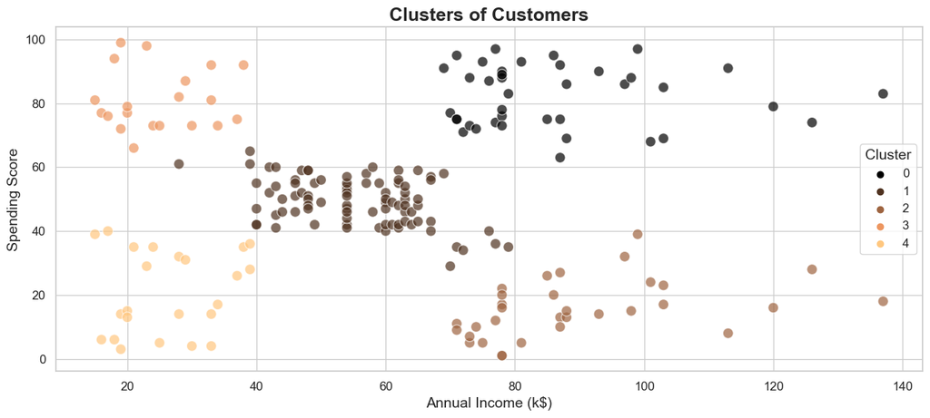

```python
import pandas as pd
from sklearn.preprocessing import MinMaxScaler
from sklearn.cluster import AgglomerativeClustering
import matplotlib.pyplot as plt
import seaborn as sns

# Drop non-numeric columns
numeric_data = data.drop(columns=['Genre'])

# Calculate mean values of each feature within each cluster
cluster_means = numeric_data.groupby('Cluster').mean()
print(cluster_means)

# Enhanced Scatter Plot of Clusters
plt.figure(figsize=(15, 6))
sns.scatterplot(
    x='Annual_Income_(k$)',
    y='Spending_Score',
    hue='Cluster',
    palette='copper',
    data=numeric_data,
    s=100,
    edgecolor='w',
    alpha=0.7
)
plt.title('Clusters of Customers', fontsize=18, weight='bold')
plt.xlabel('Annual Income (k$)', fontsize=14)
plt.ylabel('Spending Score', fontsize=14)
plt.xticks(fontsize=12)
plt.yticks(fontsize=12)
plt.legend(title='Cluster', fontsize=12, title_fontsize=14)
plt.grid(True, linestyle='-', linewidth=0.9)
plt.show()
```

### Visualizing Data Points Distribution

A bar chart helps visualize the distribution of data points among clusters, providing insights into the clustering model's performance and potential issues such as overfitting.

#### Code to Create the Plot

```
import matplotlib.pyplot as plt
import seaborn as sns

# Calculate the number of data points per cluster
data_points_per_cluster = data['Cluster'].value_counts().sort_index()
print(data_points_per_cluster)

# Create an enhanced bar chart for data points distribution
plt.figure(figsize=(12, 8))
sns.barplot(x=data_points_per_cluster.index, y=data_points_per_cluster.values, palette='viridis', edgecolor='black')
plt.title('Number of Data Points per Cluster', fontsize=18, weight='bold')
plt.xlabel('Cluster', fontsize=14)
plt.ylabel('Number of Data Points', fontsize=14)
plt.xticks(fontsize=12)
plt.yticks(fontsize=12)
plt.grid(True, linestyle='--', linewidth=0.5)

# Display the values on the bars
for index, value in enumerate(data_points_per_cluster.values):
    plt.text(index, value + 1, str(value), ha='center', fontsize=12, weight='bold')

plt.show()
```

```
Cluster
0    39
1    86
2    32
3    20
4    23
Name: count, dtype: int64
```

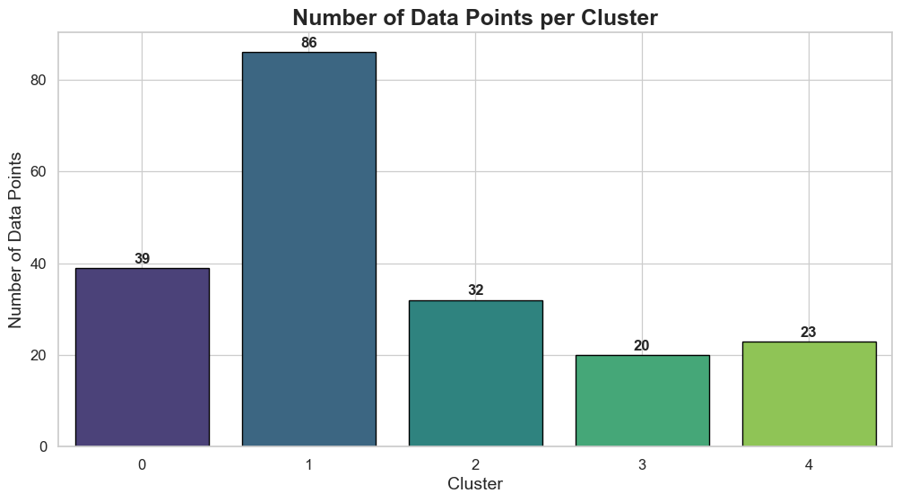

```python
import matplotlib.pyplot as plt
import seaborn as sns

# Calculate the number of data points per cluster
data_points_per_cluster = data['Cluster'].value_counts().sort_index()
print(data_points_per_cluster)

# Create an enhanced bar chart for data points distribution
plt.figure(figsize=(12, 6))
sns.barplot(x=data_points_per_cluster.index, y=data_points_per_cluster.values, palette='viridis', edgecolor='black')
plt.title('Number of Data Points per Cluster', fontsize=18, weight='bold')
plt.xlabel('Cluster', fontsize=14)
plt.ylabel('Number of Data Points', fontsize=14)
plt.xticks(fontsize=12)
plt.yticks(fontsize=12)
plt.grid(True, linestyle='-', linewidth=0.9)

# Display the values on the bars
for index, value in enumerate(data_points_per_cluster.values):
    plt.text(index, value + 1, str(value), ha='center', fontsize=12, weight='bold')

plt.show()
```

### Explanation of the Code

1. **Calculate the Number of Data Points per Cluster**:

   ```
   data_points_per_cluster = data['Cluster'].value_counts().sort_index()
   print(data_points_per_cluster)
   ```

   This line calculates the number of data points in each cluster and sorts them by cluster index. The `print` statement helps in interpreting the data points distribution.
2. **Create an Bar Chart**:

   ```
   import matplotlib.pyplot as plt
   import seaborn as sns

   plt.figure(figsize=(12, 8))
   sns.barplot(x=data_points_per_cluster.index, y=data_points_per_cluster.values, palette='viridis', edgecolor='black')
   plt.title('Number of Data Points per Cluster', fontsize=18, weight='bold')
   plt.xlabel('Cluster', fontsize=14)
   plt.ylabel('Number of Data Points', fontsize=14)
   plt.xticks(fontsize=12)
   plt.yticks(fontsize=12)
   plt.grid(True, linestyle='--', linewidth=0.5)
   ```

   - **Figure Size**: Set a larger figure size for better visibility.
   - **Bar Plot**: Use Seaborn's `barplot` function to create a bar chart with the number of data points per cluster.
     - **Palette**: Use the `viridis` color palette for a visually appealing and distinct color scheme.
     - **Edge Color**: Add black edges to the bars for better separation and readability.
   - **Title and Labels**: Add a bold title and larger font sizes for the axis labels for better readability.
   - **Ticks and Grid Lines**: Customize the font sizes of ticks and add grid lines for a cleaner appearance.
3. **Display Values on the Bars**:

   ```
   for index, value in enumerate(data_points_per_cluster.values):
       plt.text(index, value + 1, str(value), ha='center', fontsize=12, weight='bold')
   ```

   This loop adds the values of data points on top of each bar, making it easier to interpret the data points distribution.

### Insights from Data Points Distribution

The bar chart visualizing the number of data points per cluster reveals an uneven distribution. Here are the key takeaways:

1. **Cluster 0**: Contains 39 data points. This cluster represents a moderate segment of customers with similar characteristics. While not the largest, it is still significant.
2. **Cluster 1**: Contains 86 data points. This cluster is the largest, indicating that it represents the most common customer segment in the dataset.
3. **Cluster 2**: Contains 32 data points, suggesting a smaller but distinct customer segment.
4. **Cluster 3**: Contains 20 data points, indicating a smaller segment, potentially representing niche customers or outliers.
5. **Cluster 4**: Contains 23 data points. Similar to Cluster 3, this cluster represents a smaller customer segment.

**Potential Issues**:

- **Overfitting**: The presence of smaller clusters, such as Clusters 3 and 4, might indicate that the model is overfitting to specific patterns in the data, capturing noise rather than meaningful clusters.
- **Cluster Imbalance**: The imbalance in cluster sizes suggests that the clustering algorithm may not be capturing the underlying structure of the data effectively. This imbalance can impact the interpretability and usability of the clusters for practical applications like targeted marketing.

By visualizing and interpreting the data points distribution among clusters, we can better understand the clustering model's performance and identify potential issues such as overfitting or imbalanced clusters. `This helps in refining the clustering process and improving the overall analysis`.

### Recap of Clustering Process using the Best Clustering Model.

Clustering is an indispensable tool for discovering patterns and segments within data, providing valuable insights for various applications, including marketing analysis and customer segmentation. By comprehensively understanding and applying K-Means and Hierarchical Clustering, and evaluating their performance using metrics like Silhouette Score, Davies-Bouldin Index, Calinski-Harabasz Index, and the Elbow Method, we can achieve meaningful and actionable results.

**Practical Applications**:

1. **Customer Segmentation**: Clustering allows businesses to identify distinct customer groups based on purchasing behavior, demographics, and other relevant features. This enables targeted marketing strategies, personalized customer experiences, and optimized resource allocation.
2. **Market Analysis**: By segmenting the market into different clusters, businesses can identify emerging trends, understand competitive dynamics, and tailor their products or services to meet specific needs.
3. **Anomaly Detection**: Clustering helps in identifying outliers or unusual patterns in data, which can be critical for fraud detection, quality control, and risk management.
4. **Product Recommendations**: By clustering customers based on their preferences and behavior, businesses can develop more accurate and relevant product recommendation systems, enhancing customer satisfaction and loyalty.
5. **Operational Efficiency**: Clustering can streamline operations by grouping similar tasks, processes, or assets, leading to improved efficiency and reduced costs.

**Key Takeaways**:

- **Model Refinement**: Continuously experiment with different numbers of clusters and clustering algorithms to find the optimal solution.
- **Data Preprocessing**: Pay attention to feature selection, scaling, and handling outliers to improve clustering performance.
- **Visualizations**: Use advanced visualizations to interpret clustering results effectively and communicate insights clearly.
- **Performance Metrics**: Regularly evaluate clustering performance using metrics like Silhouette Score, DBI, CHI, and WCSS to ensure the model's robustness and accuracy.

This comprehensive guide aims to equip you with the knowledge and skills to perform clustering effectively, unlocking the full potential of your data for informed decision-making and strategic planning. By leveraging clustering techniques, you can uncover hidden patterns, optimize business operations, and drive growth and innovation in your organization. Happy clustering!

```
              Age  Annual_Income_(k$)  Spending_Score    Cluster
count  200.000000          200.000000      200.000000  200.00000
mean    38.850000           60.560000       50.200000    1.36000
std     13.969007           26.264721       25.823522    1.44945
min     18.000000           15.000000        1.000000    0.00000
25%     28.750000           41.500000       34.750000    0.00000
50%     36.000000           61.500000       50.000000    1.00000
75%     49.000000           78.000000       73.000000    3.00000
max     70.000000          137.000000       99.000000    4.00000
               Age  Annual_Income_(k$)  Spending_Score
Cluster
0        42.714286           55.642857       49.369048
1        32.692308           86.538462       82.128205
2        25.333333           25.095238       80.047619
3        40.454545           88.818182       16.000000
4        45.217391           26.304348       20.913043
```

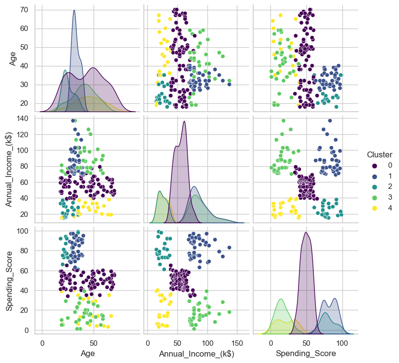

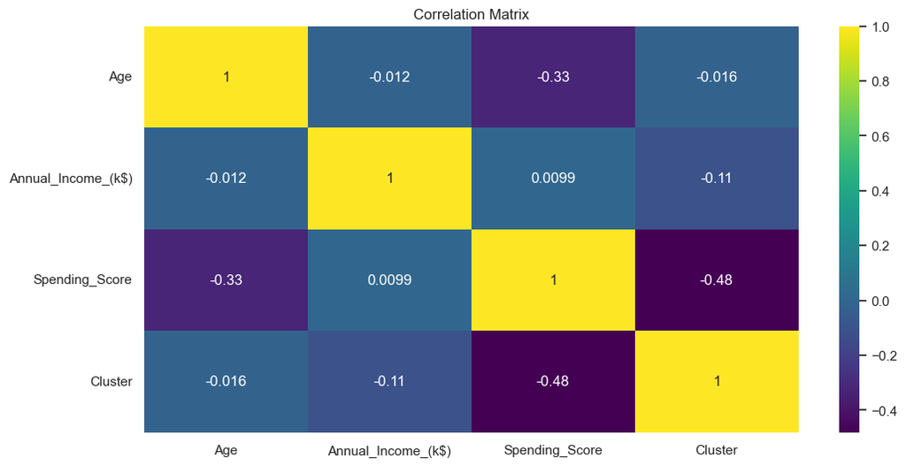

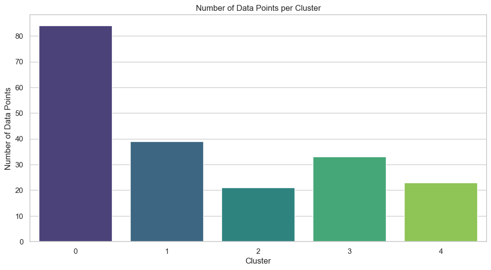

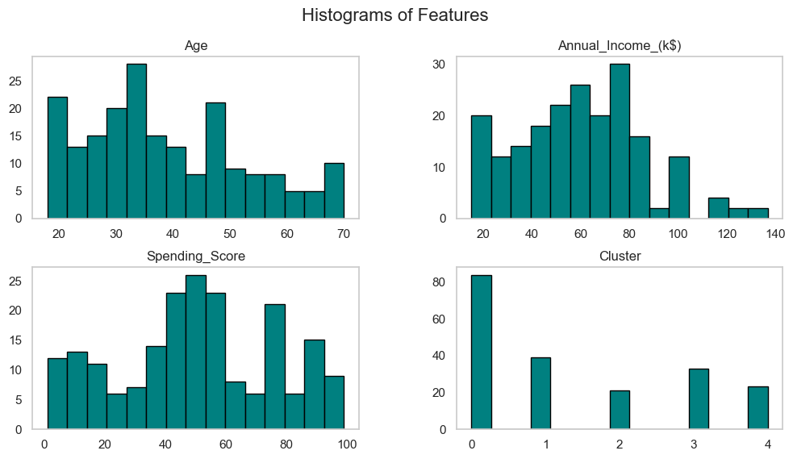

```python
import pandas as pd
from sklearn.preprocessing import MinMaxScaler
from sklearn.mixture import GaussianMixture
import matplotlib.pyplot as plt
import seaborn as sns

# Load the dataset
data = pd.read_csv('https://raw.githubusercontent.com/Explore-AI/Public-Data/master/Data/unsupervised_sprint/mall_customers.csv', index_col=0)

# Select the relevant features
X = data[['Annual_Income_(k$)', 'Spending_Score']]

# Initialize the MinMaxScaler
scaler = MinMaxScaler()

# Fit and transform the data
X_scaled = scaler.fit_transform(X)

# Initialize the Gaussian Mixture Model
cluster = GaussianMixture(n_components=5, random_state=42)

# Fit the model and predict the cluster labels
labels = cluster.fit_predict(X_scaled)

# Add the cluster labels to the original data
data['Cluster'] = labels

# Statistical summaries
print(data.describe())

# Calculate mean values of each numeric feature within each cluster
numeric_columns = ['Age', 'Annual_Income_(k$)', 'Spending_Score']
cluster_means = data.groupby('Cluster')[numeric_columns].mean()
print(cluster_means)

# Pair plots for feature interactions
plt.figure(figsize=(12, 6))
sns.pairplot(data.select_dtypes(include=['float64', 'int64']), hue='Cluster', palette='viridis')  # Exclude non-numeric columns
plt.show()

# Correlation matrix
plt.figure(figsize=(12, 6))
plt.title('Correlation Matrix')
numeric_data = data.select_dtypes(include=['float64', 'int64'])  # Select only numeric columns
corr_matrix = numeric_data.corr()
sns.heatmap(corr_matrix, annot=True, cmap='viridis', linecolor="white")
plt.show()

# Generate a bar chart of the number of data points per cluster
plt.figure(figsize=(12, 6))
sns.countplot(x='Cluster', data=data, palette='viridis')
plt.title('Number of Data Points per Cluster')
plt.xlabel('Cluster')
plt.ylabel('Number of Data Points')
plt.show()

# Histograms of features
data[numeric_data.columns].hist(figsize=(12, 6), bins=15, color='teal', edgecolor='black', grid=False)
plt.suptitle('Histograms of Features', fontsize=16)
plt.show()
```